# ROI study 2024 - updated with new employers

```r
# load packages
library(knitr)
library(tidyverse)
library(nerdify)
library(janitor)
library(rio)
library(lubridate)
library(table1)
library(lme4)
library(lmerTest)
library(lmeresampler)
library(nnet)
library(foreach)
library(doParallel)
library(car)
library(sjPlot)
library(ggplot2)
library(ggrepel)
library(cowplot)
library(marginaleffects)
library(see)
library(kableExtra)
library(gt)
```

# 1 Load data and functions

## 1.1 Claims data

```r
# Customers included in the study
customer_name <- c("Wellstar", "Pepsi", "Hearst", "Docusign", "Tegna", "Western Governors University", "IDEXX")

# Make some lists to fill up
data_funnel <- list()
df_care_use <- list()
df_appts <- list()

# Get datasets that have not yet been concatenated
for (i in 1:length(customer_name)) {
# Load data
data_funnel[[i]] <- readRDS(paste0(Sys.getenv("claims_folder_path"), "data/roi_at_scale/", customer_name[i], "/", customer_name[i], "_data_funnel.Rdata")) %>%
  mutate(customer_name = customer_name[i])
df_care_use[[i]] <- readRDS(paste0(Sys.getenv("claims_folder_path"), "data/roi_at_scale/", customer_name[i], "/", customer_name[i], "_care_use.Rdata"))
df_appts[[i]] <- readRDS(paste0(Sys.getenv("claims_folder_path"), "data/roi_at_scale/", customer_name[i], "/", customer_name[i], "_appts_by_month.Rdata"))
}

# Now bind into a single df
data_funnel <- data_funnel %>% bind_rows()
df_care_use <- df_care_use %>% bind_rows()
df_appts <- df_appts %>% bind_rows()

# Now the dfs that have previously been concatenated
df_analyze_all <- readRDS(paste0(Sys.getenv("claims_folder_path"), "data/roi_study_2023/new employer update/df_analyze_all_new_employers.Rdata"))
df_matched_orig <- readRDS(paste0(Sys.getenv("claims_folder_path"), "data/roi_study_2023/new employer update/df_matched_new_employers.Rdata"))
```

## 1.2 HEY MATT - REMEMBER TO CHECK WHETHER WE ARE PULLING BUGGY HIGH COST CONDITIONS DATA

```r
df_matched_orig %>%
  filter(months_post == 1) %>%
  group_by(customer_name, cc_any) %>%
  summarize(n = n())
```

```
## # A tibble: 14 × 3
## # Groups:   customer_name [7]
##    customer_name                cc_any     n
##    <chr>                        <chr>  <int>
##  1 Hearst                       no       972
##  2 Hearst                       yes      351
##  3 IDEXX                        no      1094
##  4 IDEXX                        yes      369
##  5 Pepsi                        no      3487
##  6 Pepsi                        yes     1580
##  7 Tegna                        no       840
##  8 Tegna                        yes      278
##  9 Wellstar                     no      1511
## 10 Wellstar                     yes      982
## 11 Western Governors University no      1167
## 12 Western Governors University yes      624
## 13 docusign                     no       630
## 14 docusign                     yes      117
```

## 1.3 Billing data

```r
# direct bill

## all direct bill appts
billing_appts <- readRDS('~/Library/CloudStorage/GoogleDrive-mhawrilenko@springhealth.com/Shared drives/ROI - Direct bill/HEOR clean/billing data.Rdata')

# Loop stuff
spring_fees <- list()
prop_matched <- vector()
for (i in 1:length(customer_name)) {

  ## Get covered life IDs for members in the study
spring_match_to_elig <- import(paste0(Sys.getenv("claims_folder_path"), "data/", customer_name[i], "/data_to_sba/", customer_name[i], "_", "eligibility_cls.csv")) %>%
  rename(any_of(c(
    carrier_member_id = "member_key",
    carrier_member_id = "indv_id",
    carrier_member_id = "individual_id"
  ))) %>%
  mutate(carrier_member_id = as.character(carrier_member_id)) %>%
  select(carrier_member_id, covered_life_id)


## Need members in the study
study_members <- df_matched_orig %>%
  distinct(carrier_member_id, spring_dummy) %>%
  left_join(spring_match_to_elig)


## Match study members to their appts
apps_query <- "SELECT appointment_id, covered_life_id
               FROM base_appointments
               WHERE UPPER(customer_name) like ?"


apps <- dbGetQuery(con = snowflake_conn("base_layer"), apps_query, params = list(paste0('%', str_to_upper(customer_name[i]), '%'))) %>%
  clean_names()


## Calculate direct bill amounts by group
spring_start_date <- df_matched_orig %>%
  ungroup() %>%
  filter(str_like(customer_name, paste0('%', .env$customer_name[i], '%'), ignore_case = TRUE)) %>%
  distinct(spring_start_date) %>%
  pull(spring_start_date)

spring_end_date <- df_matched_orig %>%
  ungroup() %>%
  filter(str_like(customer_name, paste0('%', .env$customer_name[i], '%'), ignore_case = TRUE)) %>%
  distinct(spring_end_date) %>%
  pull(spring_end_date)

direct_bill <- billing_appts %>%
  filter(str_like(customer_name, paste0('%', .env$customer_name[i], '%'), ignore_case = TRUE)) %>% #.env$customer_name
  filter(month_of_service <= spring_end_date) %>%
  left_join(apps) %>% # get covered life id
  inner_join(study_members) %>% # only individuals included in the study
  ## sometimes an individual has multiple carrier member IDs. DOn't want duplicate billing.
  ## so group by appointment_id and take first carrier_member_id
  group_by(appointment_id) %>%
  filter(carrier_member_id == first(carrier_member_id) | is.na(carrier_member_id)) %>% # address billing data that gets duped
  ungroup() %>%
  summarize(amount = sum(total_billed, na.rm=T)) %>%
  pull(amount)


billing_all <- import(paste0(Sys.getenv("claims_folder_path"), "data/", customer_name[i], "/", customer_name[i], "_", "billing.xlsx")) %>%
  clean_names()

bundle_fee <- billing_all %>%
  filter(str_like(account, paste0('%', "bundle", '%'), ignore_case = TRUE)) %>%
  summarize(bundle_fee = sum(amount, na.rm=T)) %>%
  pull(bundle_fee)

platform_fee <- billing_all %>%
  filter(str_like(account, paste0('%', "platform", '%'), ignore_case = TRUE)) %>%
  summarize(platform_fee = sum(amount, na.rm=T)) %>%
  pull(platform_fee)

billed_to_health_plan <- readRDS(paste0(Sys.getenv("claims_folder_path"), "data/roi_at_scale/", customer_name[i], "/", customer_name[i], "_spring_med_claims.Rdata")) %>%
  filter(month_year <= spring_end_date) %>%
  mutate(carrier_member_id = as.character(carrier_member_id)) %>%
  inner_join(study_members) %>%
  ungroup() %>%
  summarize(billed_to_health_plan = sum(allowed_amt, na.rm=T)) %>%
  pull(billed_to_health_plan)


## Get number of eligible employees on the health plan in the date range
elig <- readRDS(file = paste0(Sys.getenv("claims_folder_path"), "/data/roi_at_scale/", customer_name[i], "/", customer_name[i], "_carrier_elig.Rdata")) %>%
  filter(month_year >= spring_start_date) %>%
  filter(month_year <= spring_end_date) %>%
  filter(employee_flag == "yes")

## Get total employees
qry <- "SELECT DISTINCT a.customer_name, a.customer_id, id, dependent, b.created_at
                  FROM ds_trunk.base_layer.base_customers AS a
                  LEFT JOIN stitch_new.rotom_prod_replica.covered_lives AS b
                  ON a.customer_id = b.customer_id
                  WHERE UPPER(a.customer_name) LIKE ?
                  AND dependent = 'FALSE'
                  AND DATE(b.created_at) <= date(?)"

cl <- dbGetQuery(con = snowflake_conn("rotom"), qry, params = list(paste0('%', str_to_upper(customer_name[i]), '%'), spring_end_date)) %>%
  clean_names()

prop_on_health_plan <- n_distinct(elig$carrier_member_id) / n_distinct(cl$id)

cust_funnel <- data_funnel %>%
  filter(customer_name == .env$customer_name[i])
prop_matched <- pull(cust_funnel[7,4] / cust_funnel[1,4])

# Compile all fees
spring_fees[[i]] <- data.frame(
  fee_type = c("Bundle", "Platform", "Direct bill", "Billed to Health Plan")
) %>%
  mutate(
    customer_name = customer_name[i],
    prop_on_health_plan = prop_on_health_plan,
    prop_matched = prop_matched,
    Amount = case_when(
      fee_type == "Bundle" ~ bundle_fee * prop_on_health_plan * prop_matched,
      fee_type == "Platform" ~ platform_fee * prop_on_health_plan * prop_matched,
      fee_type == "Direct bill" ~ direct_bill,
      fee_type == "Billed to Health Plan" ~ billed_to_health_plan
    )
)
}
```

[output not shown]

```r
spring_fees <- spring_fees %>% bind_rows()

spring_fees %>%
  group_by(customer_name) %>%
  summarize(amount = sum(Amount, na.rm=T))
```

```
## # A tibble: 7 × 2
##   customer_name                  amount
##   <chr>                           <dbl>
## 1 Docusign                      197853.
## 2 Hearst                        686648.
## 3 IDEXX                         767480.
## 4 Pepsi                        2214915.
## 5 Tegna                         420328.
## 6 Wellstar                     1058724.
## 7 Western Governors University  605682.
```

```r
total_invoiced <- spring_fees %>%
  summarize(amount = sum(Amount, na.rm=T)) %>%
  pull(amount)

# Get monthly Spring costs
member_months <- df_matched_orig %>% ungroup() %>% filter(spring_dummy == "Spring", months_post>=1) %>% summarize(n=n()) %>% pull()
spring_pmpm_adjustment <- total_invoiced/member_months
effective_session_fee <- sum(spring_fees$Amount) / sum(df_matched_orig$spring_tx_count_month, na.rm = T)
```

# 2 Analyze utilization pre and post launch

Spring promises to drive value by getting more people into care who otherwise would never have received it. Here, we test this premise by determining how much mental health treatment utilization changed after Spring launched. Here, we examine 3 metrics:  
1. How annual outpatient behavioral health treatment utilization changed pre and post Spring  
2. Any utilization by month  
3. Number of sessions per month

# 3 Annual utilization

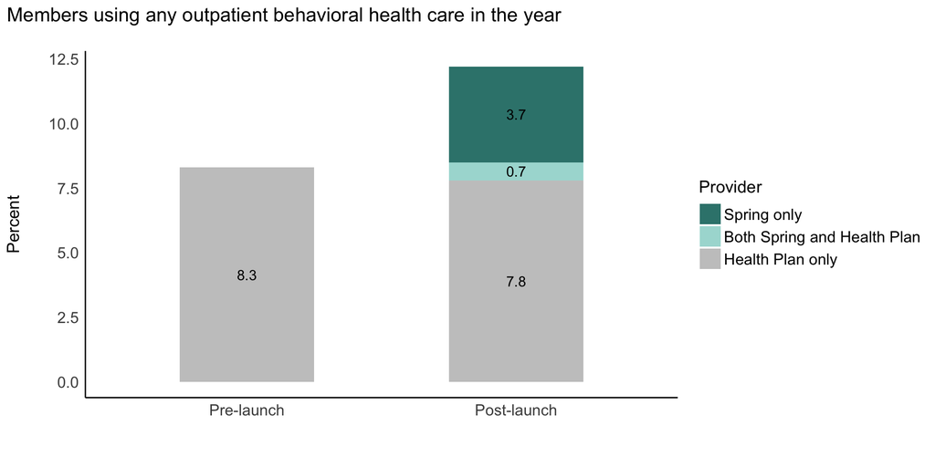

```r
df_phase_summary <- df_care_use %>%
  filter(month_year >= baseline_start_date) %>%
  filter(month_year <= spring_end_date) %>%
  mutate(phase = ifelse(month_year < spring_start_date, "Pre-launch", "Post-launch")) %>%
  mutate(phase = factor(phase, levels = c("Pre-launch", "Post-launch"))) %>%
  group_by(customer_name, carrier_member_id, phase) %>%
  summarize(
    carrier_tx_count_month = sum(carrier_tx_count_month),
    spring_tx_count_month = sum(spring_tx_count_month),
    carrier_therapist_count_month = sum(carrier_therapist_count_month),
    spring_therapist_count_month = sum(spring_therapist_count_month)
  ) %>%
  ungroup() %>%
  mutate(
    mh_appt_group = factor(case_when(
      carrier_tx_count_month > 0 & spring_tx_count_month > 0 ~ "Both Spring and Health Plan",
      carrier_tx_count_month > 0 & spring_tx_count_month == 0 ~ "Health Plan only",
      carrier_tx_count_month == 0 & spring_tx_count_month > 0 ~ "Spring only",
      carrier_tx_count_month == 0 & spring_tx_count_month == 0 ~ "No appointments"
    ),
    levels = c("Spring only", "Both Spring and Health Plan", "Health Plan only", "No appointments")
    ))

care_use_avg <- df_phase_summary %>%
  group_by(customer_name, phase, mh_appt_group) %>%
  summarize(group_n = n()) %>%
  group_by(customer_name, phase) %>%
  mutate(proportion = group_n/sum(group_n)) %>%
  filter(mh_appt_group != "No appointments") %>%
  group_by(phase, mh_appt_group) %>%
  summarize(proportion = mean(proportion)) %>%
  mutate(proportion = round(100*proportion, 1))


# Plot
color_scheme <- c("#37837c","#A9DbD6", '#c7c7c7') # set colors

## plot
ggplot(care_use_avg, aes(x = phase, y=proportion, group = mh_appt_group, fill = mh_appt_group)) +
  geom_bar(position="stack", stat="identity", width = 0.5) +
  scale_fill_manual(values = color_scheme, name = "Provider") +
  geom_text(aes(label=proportion), position = position_stack(vjust = 0.5), colour = "black") +
  theme_modern() +
  labs(
    title = "Members using any outpatient behavioral health care in the year",
    x = "",
    y = "Percent",
    group = "",
    fill = ""
  )
```

```r
# Model

## Overall
df_phase_summary <- df_phase_summary %>%
  mutate(any_utilization = ifelse(mh_appt_group == "No appointments", "no", "yes"))

m_overall_util <- multinom(any_utilization ~ -1 + customer_name:phase,
            data = df_phase_summary)
mnom_avg <- function(x) exp(x) / (1 + exp(x))
hypotheses(m_overall_util, "(
           (exp(b1) / (1 + exp(b1))) +
           (exp(b2) / (1 + exp(b2))) +
           (exp(b3) / (1 + exp(b3))) +
           (exp(b4) / (1 + exp(b4))) +
           (exp(b5) / (1 + exp(b5))) +
           (exp(b6) / (1 + exp(b6))) +
           (exp(b7) / (1 + exp(b7)))
           ) / 7 = 0
           ")
```

```
##
##                                                                                                                                                                                                                                                                                                          …
##  (\n           (exp(b1) / (1 + exp(b1))) +\n           (exp(b2) / (1 + exp(b2))) +\n           (exp(b3) / (1 + exp(b3))) +\n           (exp(b4) / (1 + exp(b4))) +\n           (exp(b5) / (1 + exp(b5))) +\n           (exp(b6) / (1 + exp(b6))) +\n           (exp(b7) / (1 + exp(b7))) \n           ) /…
##  Estimate Std. Error    z Pr(>|z|)  2.5 % 97.5 %
##    0.0831   0.000906 91.7   <0.001 0.0813 0.0849
##
## Columns: term, estimate, std.error, statistic, p.value, conf.low, conf.high
```

```r
predictions(m_overall_util, newdata = df_phase_summary %>% distinct(customer_name, phase), type = "probs") %>%
  arrange(phase)
```

```
##
##  Group Estimate Std. Error     z Pr(>|z|)  2.5 % 97.5 %
##    yes   0.1067   0.002445  43.6   <0.001 0.1019 0.1115
##    yes   0.1229   0.002809  43.7   <0.001 0.1174 0.1284
##    yes   0.0509   0.000448 113.7   <0.001 0.0501 0.0518
##    yes   0.1009   0.002900  34.8   <0.001 0.0952 0.1065
##    yes   0.0650   0.001207  53.8   <0.001 0.0626 0.0674
##    yes   0.0224   0.001211  18.5   <0.001 0.0200 0.0247
##    yes   0.1128   0.003854  29.3   <0.001 0.1053 0.1204
##    yes   0.1497   0.002776  53.9   <0.001 0.1442 0.1551
##    yes   0.1721   0.003264  52.7   <0.001 0.1657 0.1785
##    yes   0.0597   0.000466 128.1   <0.001 0.0588 0.0606
##    yes   0.1444   0.003336  43.3   <0.001 0.1379 0.1510
##    yes   0.0941   0.001419  66.3   <0.001 0.0913 0.0969
##    yes   0.0738   0.002039  36.2   <0.001 0.0698 0.0778
##    yes   0.1627   0.003945  41.2   <0.001 0.1550 0.1705
##                 customer_name       phase
##  Hearst                       Pre-launch
##  IDEXX                        Pre-launch
##  Pepsi                        Pre-launch
##  Tegna                        Pre-launch
##  Wellstar                     Pre-launch
##  Western Governors University Pre-launch
##  docusign                     Pre-launch
##  Hearst                       Post-launch
##  IDEXX                        Post-launch
##  Pepsi                        Post-launch
##  Tegna                        Post-launch
##  Wellstar                     Post-launch
##  Western Governors University Post-launch
##  docusign                     Post-launch
##
## Columns: rowid, group, estimate, std.error, statistic, p.value, conf.low, conf.high, customer_name, phase, any_utilization
```

```r
## Model pre-phase
m1_util <- multinom(mh_appt_group ~ customer_name,
            data = filter(df_phase_summary, phase == "Pre-launch"))
## Model post-phase
m2_util <- multinom(mh_appt_group ~ customer_name,
            data = filter(df_phase_summary, phase == "Post-launch"))
predictions(m1_util, newdata = df_phase_summary %>% distinct(customer_name), type = "probs")
```

```
##
##            Group Estimate Std. Error    z Pr(>|z|) 2.5 % 97.5 %
##  No appointments    0.893   0.002445  365   <0.001 0.888  0.898
##  No appointments    0.877   0.002808  312   <0.001 0.872  0.883
##  No appointments    0.949   0.000448 2119   <0.001 0.948  0.950
##  No appointments    0.899   0.002899  310   <0.001 0.893  0.905
##  No appointments    0.935   0.001207  774   <0.001 0.933  0.937
##  No appointments    0.978   0.001211  807   <0.001 0.975  0.980
##  No appointments    0.887   0.003854  230   <0.001 0.880  0.895
##                 customer_name
##  Hearst
##  IDEXX
##  Pepsi
##  Tegna
##  Wellstar
##  Western Governors University
##  docusign
##
## Columns: rowid, group, estimate, std.error, statistic, p.value, conf.low, conf.high, customer_name, mh_appt_group
```

```r
predictions(m2_util, newdata = df_phase_summary %>% distinct(customer_name), type = "probs")
```

```
##
##                        Group Estimate Std. Error       z Pr(>|z|)   2.5 %
##  Spring only                  0.03463   0.001423   24.34   <0.001 0.03184
##  Spring only                  0.04805   0.001850   25.98   <0.001 0.04443
##  Spring only                  0.00780   0.000173   45.09   <0.001 0.00746
##  Spring only                  0.04644   0.001997   23.25   <0.001 0.04252
##  Spring only                  0.02608   0.000774   33.68   <0.001 0.02456
##  Spring only                  0.05307   0.001748   30.35   <0.001 0.04964
##  Spring only                  0.04484   0.002212   20.27   <0.001 0.04051
##  Both Spring and Health Plan  0.00850   0.000714   11.90   <0.001 0.00710
##  Both Spring and Health Plan  0.01115   0.000908   12.28   <0.001 0.00937
##  Both Spring and Health Plan  0.00134   0.000072   18.66   <0.001 0.00120
##  Both Spring and Health Plan  0.00508   0.000675    7.53   <0.001 0.00376
##  Both Spring and Health Plan  0.00569   0.000366   15.57   <0.001 0.00498
##  Both Spring and Health Plan  0.00261   0.000398    6.56   <0.001 0.00183
##  Both Spring and Health Plan  0.01423   0.001266   11.24   <0.001 0.01175
##  Health Plan only             0.10647   0.002400   44.36   <0.001 0.10176
##  Health Plan only             0.11268   0.002734   41.21   <0.001 0.10732
##  Health Plan only             0.05052   0.000431  117.31   <0.001 0.04967
##  Health Plan only             0.09294   0.002756   33.73   <0.001 0.08754
##  Health Plan only             0.06240   0.001175   53.09   <0.001 0.06010
##  Health Plan only             0.01818   0.001042   17.45   <0.001 0.01614
##  Health Plan only             0.10367   0.003258   31.82   <0.001 0.09728
##  No appointments              0.85040   0.002776  306.39   <0.001 0.84496
##  No appointments              0.82812   0.003263  253.81   <0.001 0.82172
##  No appointments              0.94034   0.000466 2019.18   <0.001 0.93943
##  No appointments              0.85554   0.003337  256.41   <0.001 0.84900
##  No appointments              0.90583   0.001419  638.26   <0.001 0.90304
##  No appointments              0.92614   0.002040  453.99   <0.001 0.92214
##  No appointments              0.83726   0.003945  212.23   <0.001 0.82953
##   97.5 %                customer_name
##  0.03742 Hearst
##  0.05168 IDEXX
##  0.00814 Pepsi
##  0.05035 Tegna
##  0.02760 Wellstar
##  0.05649 Western Governors University
##  0.04918 docusign
##  0.00990 Hearst
##  0.01293 IDEXX
##  0.00149 Pepsi
##  0.00641 Tegna
##  0.00641 Wellstar
##  0.00339 Western Governors University
##  0.01671 docusign
##  0.11117 Hearst
##  0.11803 IDEXX
##  0.05136 Pepsi
##  0.09834 Tegna
##  0.06471 Wellstar
##  0.02022 Western Governors University
##  0.11005 docusign
##  0.85584 Hearst
##  0.83451 IDEXX
##  0.94125 Pepsi
##  0.86208 Tegna
##  0.90861 Wellstar
##  0.93014 Western Governors University
##  0.84499 docusign
##
## Columns: rowid, group, estimate, std.error, statistic, p.value, conf.low, conf.high, customer_name, mh_appt_group
```

## 3.1 Monthly utilization

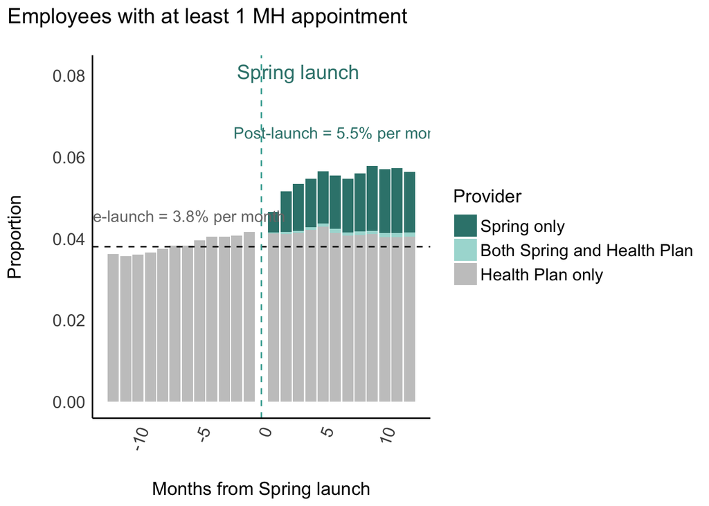

```r
# Monthly utilization
plot_monthly_avg <- df_care_use %>%
  filter(month_year >= baseline_start_date) %>%
  filter(month_year <= spring_end_date) %>%
  mutate(
    months_std = case_when(
      month_year < spring_start_date ~ interval(spring_start_date, month_year) %/% months(1),
      month_year >= spring_start_date ~ interval(spring_start_date, month_year) %/% months(1) + 1
    ),
    phase = ifelse(month_year < spring_start_date, "Pre-launch", "Post-launch"),
    provider = "Spring"
    ) %>%
  group_by(customer_name, mh_appt_group, months_std) %>%
  summarize(
    mh_appt_in_month = sum(mh_appt_in_month == "yes"),
    group_n = n()
    ) %>%
  group_by(customer_name, months_std) %>%
  mutate(n = sum(group_n)) %>%
  mutate(
    mh_appt_in_month_proportion = mh_appt_in_month/n,
    mh_appt_group = case_when(
      mh_appt_group == "Carrier only" ~ "Health Plan only",
      mh_appt_group == "Both Spring and Carrier" ~ "Both Spring and Health Plan",
      TRUE ~ mh_appt_group)
    ) %>%
  mutate(mh_appt_group = factor(mh_appt_group, levels = c("Spring only", "Both Spring and Health Plan", "Health Plan only"))) %>%
  filter(mh_appt_group != "No appointments") %>%
  group_by(months_std, mh_appt_group) %>%
  summarize(mh_appt_in_month_proportion = mean(mh_appt_in_month_proportion)) %>%
  arrange(mh_appt_group, months_std)


## Plot

## Make some plotting locations
pre_mean_avg <- round(
  sum(plot_monthly_avg$mh_appt_in_month_proportion[plot_monthly_avg$months_std < 0])/12,
  3)
post_mean_avg <- round(
  sum(plot_monthly_avg$mh_appt_in_month_proportion[plot_monthly_avg$months_std > 0])/12,
  3)
max_avg <-max(
  plot_monthly_avg %>%
    group_by(months_std) %>%
    summarize(apps_in_month = sum(mh_appt_in_month_proportion)) %>%
    pull(apps_in_month)
)

## Plot
ggplot(plot_monthly_avg, aes(x = months_std, y=mh_appt_in_month_proportion, group = mh_appt_group, fill = mh_appt_group)) +
  geom_bar(position="stack", stat="identity") +
  scale_fill_manual(values = color_scheme, name = "Provider") +
  theme_modern() +
  geom_hline(yintercept = pre_mean_avg, linetype = "dashed") +
  geom_vline(xintercept = 0, color = "#48ADA3", linetype = "dashed") +
  theme(axis.text.x = element_text(angle = 70, vjust = 1, hjust=1)) +
  annotate(geom = "text", x = 3, y = max_avg*1.4, label = "Spring launch", color = "#37837c", size = 5) +
  annotate(geom = "text", x = -6.5, y = pre_mean_avg*1.2, label = paste0("Pre-launch = ", 100*pre_mean_avg, "% per month"), color = "#767676", size = 4) +
  annotate(geom = "text", x = 6.5, y = post_mean_avg*1.2, label = paste0("Post-launch = ", 100*post_mean_avg, "% per month"), color = "#37837c", size = 4) +
  labs(
    title = "Employees with at least 1 MH appointment",
    x = "Months from Spring launch",
    y = "Proportion"
  )
```

# 4 Cohort comparisons

To determine Spring’s impact on Wellstar, Pepsi, Hearst, Docusign, Tegna, Western Governors University, IDEXX’s total cost of care, we conducted a matching study. We identified the group of people who engaged with a Spring provider, a risk-matched group that did not use Spring, and compared the spend of both groups. Research demonstrates that spend increases at the time of a mental health diagnosis, so we compared changes in each group’s spending from the year prior to receiving a MH diagnosis to the year after receiving a diagnosis, using a difference-in-differences design.

## 4.1 Data funnel

This table shows each step where participants were funneled into the analytic sample.

```r
match_funnel <- df_matched_orig %>%
  group_by(spring_dummy) %>%
  summarize(
    n = n_distinct(carrier_member_id),
    filter_name = "Maintained in matching study"
    ) %>%
  mutate(total_n = sum(n)) %>%
  pivot_wider(
    id_cols = c(filter_name, total_n),
    names_from = spring_dummy,
    values_from = n
  )

data_funnel %>%
  group_by(filter_name) %>%
  summarize(across(-customer_name, sum)) %>%
  rbind(match_funnel) %>%
  arrange(-total_n) %>%
  kbl(caption = "Participant funnel through inclusion criteria") %>%
  kable_classic(full_width = T, html_font = "Cambria")
```

Participant funnel through inclusion criteria

| filter_name | total_n | Health Plan | Spring |
| --- | --- | --- | --- |
| Insured by Health Plan any time in study year | 373879 | 366661 | 7218 |
| Mental health diagnosis after Spring launch | 67295 | 60089 | 7206 |
| Aged 5 and older | 41303 | 35654 | 5649 |
| Member must have 6 months pre and 1 months post | 40899 | 35273 | 5626 |
| Filter out patients with transplants or end-stage renal disease | 40829 | 35209 | 5620 |
| Did not receive treatment from both Spring and Health Plan | 40158 | 35209 | 4949 |
| No previous mental health diagnosis within 6 months of study year diagnosis | 33665 | 29997 | 3668 |
| Maintained in matching study | 13971 | 9066 | 4905 |
| No previous mental health treatment within 6 months of study year diagnosis | 8872 | 6890 | 1982 |

## 4.2 Summarize unmatched data

Prior to conducting matching, we examined key risk characteristics of the pool of potential study participants. From this table, we can see that prior to match, the Spring group consisted of slightly more women, more individuals in the 25-44 age category, had slightly lower medical spending risk scores, and comparatively more mood and anxiety diagnoses and fewer substance use diagnoses.

```r
df_unmatched_table <- df_analyze_all %>%
  filter(index_date >= spring_start_date) %>%
  group_by(carrier_member_id, spring_dummy, age_at_index, member_sex, cc_any, cc_asthma_copd, cc_diabetes, cc_hypertension, cc_heart, cc_stroke, cc_kidney, cc_osteo, cc_cancer) %>%
  arrange(month_year) %>%
  summarize(
    carrier_mh_dx = first(carrier_primary_mh_dx, na_rm = TRUE),
    spring_mh_dx = first(spring_primary_mh_dx, na_rm = TRUE),
    risk_score_dx = risk_score[months == 1]
  ) %>%
  ungroup() %>%
  mutate(mh_dx = coalesce(spring_mh_dx, carrier_mh_dx)) %>%
  mutate(dx_collapsed = fct_collapse(mh_dx,
                                   mood = "mood",
                                   anxiety = "anxiety",
                                   sud = "sud",
                                   other = c("personality", "psychotic", "intellectual disability", "physical behavioral", "physiological", "developmental", "child onset", "unspecified")
  )) %>%
  select(-c(carrier_mh_dx, spring_mh_dx)) %>%
  ungroup()

## Examine overall table
### NOTE: p-value function is broken so currently dropping
table1( ~ age_at_index + member_sex + mh_dx + dx_collapsed + risk_score_dx + cc_any + cc_asthma_copd + cc_diabetes + cc_hypertension + cc_heart
        + cc_stroke + cc_kidney + cc_osteo + cc_cancer | spring_dummy,
        overall = F,
        render.missing = NULL,
       render.categorical = "FREQ (PCTnoNA%)",
        data=df_unmatched_table)
```

|  | Health Plan (N=35209) | Spring (N=4950) |
| --- | --- | --- |
| age_at_index |  |  |
| Mean (SD) | 34.9 (16.1) | 37.3 (11.8) |
| Median [Min, Max] | 35.0 [5.00, 96.0] | 36.0 [6.00, 74.0] |
| member_sex |  |  |
| female | 19404 (55.1%) | 3308 (66.8%) |
| male | 15799 (44.9%) | 1641 (33.2%) |
| mh_dx |  |  |
| mood | 6864 (19.7%) | 826 (20.8%) |
| anxiety | 16550 (47.4%) | 2927 (73.6%) |
| sud | 4572 (13.1%) | 110 (2.77%) |
| personality | 166 (0.476%) | 13 (0.327%) |
| psychotic | 93 (0.267%) | 0 (0%) |
| physical behavioral | 1381 (3.96%) | 16 (0.402%) |
| physiological | 250 (0.717%) | 5 (0.126%) |
| intellectual disability | 22 (0.0631%) | 0 (0%) |
| developmental | 801 (2.30%) | 9 (0.226%) |
| child onset | 4160 (11.9%) | 71 (1.78%) |
| unspecified | 26 (0.0745%) | 1 (0.0251%) |
| dx_collapsed |  |  |
| mood | 6864 (19.7%) | 826 (20.8%) |
| anxiety | 16550 (47.4%) | 2927 (73.6%) |
| sud | 4572 (13.1%) | 110 (2.77%) |
| other | 6899 (19.8%) | 115 (2.89%) |
| risk_score_dx |  |  |
| Mean (SD) | 1.84 (4.83) | 1.36 (3.41) |
| Median [Min, Max] | 0.494 [0.102, 120] | 0.458 [0.102, 50.4] |
| cc_any |  |  |
| no | 23109 (65.6%) | 3566 (72.0%) |
| yes | 12100 (34.4%) | 1384 (28.0%) |
| cc_asthma_copd |  |  |
| no | 31706 (90.1%) | 4509 (91.1%) |
| yes | 3503 (9.95%) | 441 (8.91%) |
| cc_diabetes |  |  |
| no | 32768 (93.1%) | 4651 (94.0%) |
| yes | 2441 (6.93%) | 299 (6.04%) |
| cc_hypertension |  |  |
| no | 27287 (77.5%) | 4127 (83.4%) |
| yes | 7922 (22.5%) | 823 (16.6%) |
| cc_heart |  |  |
| no | 34090 (96.8%) | 4864 (98.3%) |
| yes | 1119 (3.18%) | 86 (1.74%) |
| cc_stroke |  |  |
| no | 34981 (99.4%) | 4933 (99.7%) |
| yes | 228 (0.648%) | 17 (0.343%) |
| cc_kidney |  |  |
| no | 34775 (98.8%) | 4913 (99.3%) |
| yes | 434 (1.23%) | 37 (0.747%) |
| cc_osteo |  |  |
| no | 34908 (99.1%) | 4909 (99.2%) |
| yes | 301 (0.855%) | 41 (0.828%) |
| cc_cancer |  |  |
| no | 33904 (96.3%) | 4818 (97.3%) |
| yes | 1305 (3.71%) | 132 (2.67%) |

## 4.3 Summarize matched data

```r
df_match_table <- df_matched_orig %>%
  group_by(carrier_member_id) %>%
  arrange(months) %>%
  mutate(
    therapy_sessions_cum = case_when(
      spring_dummy == "Spring" ~ cumsum(spring_therapist_count_month),
      spring_dummy == "Health Plan" ~ cumsum(carrier_therapist_count_month)
    ),
    therapy_sessions_total = sum(spring_therapist_count_month, carrier_therapist_count_month, na.rm=T),
    session_count_total = sum(spring_tx_count_month, carrier_tx_count_month, na.rm=T),
    months_diagnosed = interval(index_date, spring_end_date) %/% months(1) + 1,
    cc_any2 = case_when(
      cc_cancer == "yes" ~ "yes",
      cc_hypertension == "yes" ~ "yes",
      cc_diabetes == "yes" ~ "yes",
      excl_pregnancy == "yes" ~ "yes",
      cc_asthma_copd == "yes" ~ "yes",
      TRUE ~ "no"
    )
  ) %>%
  mutate(
    any_bh = ifelse(session_count_total > 0, "yes", "no"),
    bh_if_engaged = ifelse(session_count_total > 0, session_count_total, NA),
    therapy_if_engaged = ifelse(therapy_sessions_total > 0, therapy_sessions_total, NA)
    ) %>%
  group_by(carrier_member_id, cc_any2, cc_asthma_copd, cc_diabetes, cc_hypertension, cc_cancer, excl_pregnancy) %>%
  arrange(months) %>%
  slice_head() %>%
  ungroup() %>%
  mutate(spring_dummy = factor(spring_dummy, labels = c("Control", "Spring Health")))


# Add labels
label(df_match_table$age_at_index) <- "Age"
label(df_match_table$member_sex) <- "Sex (assigned at birth)"
label(df_match_table$dx_imputed) <- "Mental health diagnosis"
label(df_match_table$risk_score_dx) <- "Risk score at time of diagnosis"
label(df_match_table$months_diagnosed) <- "Months with diagnosis"
label(df_match_table$therapy_sessions_total) <- "Number of therapy sessions"
label(df_match_table$session_count_total) <- "Number of behavioral health sessions, all participants"
label(df_match_table$any_bh) <- "Engaged in outpatient behavioral health treatment"
label(df_match_table$bh_if_engaged) <- "Number of behavioral health sessions, engagers only"

# NOTE: p-value function is broken here so currently dropping
table1( ~ age_at_index + member_sex + dx_imputed + risk_score_dx + months_diagnosed + cc_any2 + cc_asthma_copd + cc_diabetes + cc_hypertension + cc_kidney + cc_osteo + cc_cancer + excl_pregnancy | spring_dummy,
        overall = F,
        footnote = "This table is based on raw values. In cases where 2 matches were not achieved, weights were applied.",
        data=df_match_table)
```

|  | Control (N=9066) | Spring Health (N=4905) |
| --- | --- | --- |
| Age |  |  |
| Mean (SD) | 37.2 (14.0) | 37.4 (11.8) |
| Median [Min, Max] | 37.0 [5.00, 85.0] | 36.0 [6.00, 74.0] |
| Sex (assigned at birth) |  |  |
| female | 5864 (64.7%) | 3280 (66.9%) |
| male | 3202 (35.3%) | 1625 (33.1%) |
| Mental health diagnosis |  |  |
| mood | 1982 (21.9%) | 1017 (20.7%) |
| anxiety | 6534 (72.1%) | 3609 (73.6%) |
| sud | 270 (3.0%) | 138 (2.8%) |
| other | 280 (3.1%) | 141 (2.9%) |
| Risk score at time of diagnosis |  |  |
| Mean (SD) | 1.33 (3.29) | 1.32 (3.25) |
| Median [Min, Max] | 0.458 [0.102, 54.7] | 0.458 [0.102, 50.4] |
| Months with diagnosis |  |  |
| Mean (SD) | 6.55 (3.41) | 6.52 (3.47) |
| Median [Min, Max] | 6.00 [1.00, 12.0] | 6.00 [1.00, 12.0] |
| cc_any2 |  |  |
| no | 5883 (64.9%) | 3384 (69.0%) |
| yes | 3183 (35.1%) | 1521 (31.0%) |
| cc_asthma_copd |  |  |
| no | 8320 (91.8%) | 4466 (91.1%) |
| yes | 746 (8.2%) | 439 (9.0%) |
| cc_diabetes |  |  |
| no | 8491 (93.7%) | 4612 (94.0%) |
| yes | 575 (6.3%) | 293 (6.0%) |
| cc_hypertension |  |  |
| no | 7086 (78.2%) | 4090 (83.4%) |
| yes | 1980 (21.8%) | 815 (16.6%) |
| cc_kidney |  |  |
| no | 8972 (99.0%) | 4869 (99.3%) |
| yes | 94 (1.0%) | 36 (0.7%) |
| cc_osteo |  |  |
| no | 8980 (99.1%) | 4865 (99.2%) |
| yes | 86 (0.9%) | 40 (0.8%) |
| cc_cancer |  |  |
| no | 8782 (96.9%) | 4776 (97.4%) |
| yes | 284 (3.1%) | 129 (2.6%) |
| excl_pregnancy |  |  |
| no | 8637 (95.3%) | 4652 (94.8%) |
| yes | 429 (4.7%) | 253 (5.2%) |

This table is based on raw values. In cases where 2 matches were not achieved, weights were applied.

```r
# Drop median, min, max
render.cont <- function(x) {
    with(stats.apply.rounding(stats.default(round(x, 1)), digits=3), c("",
        "Mean (SD)"=sprintf("%s (%s)", MEAN, SD)))
}

table1( ~ age_at_index + age_factor + member_sex + dx_imputed + risk_score_dx + months_diagnosed + any_bh + bh_if_engaged | spring_dummy,
        overall = F,
        render.continuous = render.cont,
        footnote = "This table is based on raw values. In cases where 2 matches were not achieved, weights were applied.",
        data=df_match_table)
```

|  | Control (N=9066) | Spring Health (N=4905) |
| --- | --- | --- |
| Age |  |  |
| Mean (SD) | 37.2 (14.0) | 37.4 (11.8) |
| age_factor |  |  |
| 0 to 5 | 29 (0.3%) | 0 (0%) |
| 11 to 17 | 628 (6.9%) | 149 (3.0%) |
| 18 to 24 | 1025 (11.3%) | 347 (7.1%) |
| 25 to 34 | 2200 (24.3%) | 1698 (34.6%) |
| 35 to 44 | 2156 (23.8%) | 1349 (27.5%) |
| 45 to 54 | 1750 (19.3%) | 872 (17.8%) |
| 55 to 64 | 996 (11.0%) | 408 (8.3%) |
| 6 to 10 | 152 (1.7%) | 35 (0.7%) |
| 65 and over | 130 (1.4%) | 47 (1.0%) |
| Sex (assigned at birth) |  |  |
| female | 5864 (64.7%) | 3280 (66.9%) |
| male | 3202 (35.3%) | 1625 (33.1%) |
| Mental health diagnosis |  |  |
| mood | 1982 (21.9%) | 1017 (20.7%) |
| anxiety | 6534 (72.1%) | 3609 (73.6%) |
| sud | 270 (3.0%) | 138 (2.8%) |
| other | 280 (3.1%) | 141 (2.9%) |
| Risk score at time of diagnosis |  |  |
| Mean (SD) | 1.34 (3.29) | 1.32 (3.25) |
| Months with diagnosis |  |  |
| Mean (SD) | 6.55 (3.41) | 6.52 (3.47) |
| Engaged in outpatient behavioral health treatment |  |  |
| no | 5982 (66.0%) | 0 (0%) |
| yes | 3084 (34.0%) | 4905 (100%) |
| Number of behavioral health sessions, engagers only |  |  |
| Mean (SD) | 7.31 (8.32) | 4.68 (4.76) |
| Missing | 5982 (66.0%) | 0 (0%) |

This table is based on raw values. In cases where 2 matches were not achieved, weights were applied.

```r
# This is better with p-values but formatting is ugly
library(survey)
library(tableone)
t1_design <- svydesign(ids = ~carrier_member_id, strata = ~spring_dummy, weights = ~weights_nn,
                       nest = TRUE, data = df_match_table)

t1 <- svyCreateTableOne(
  vars = c("age_at_index", "member_sex", "dx_imputed", "risk_score_dx", "months_diagnosed",
           "cc_asthma_copd", "cc_diabetes", "cc_hypertension", "cc_cancer", "excl_pregnancy", "any_bh", "bh_if_engaged"),
  strata = "spring_dummy",
  data = t1_design)

t1 %>%
  kableone() %>%
  kable_classic(full_width = FALSE, html_font = "Cambria") %>%
  remove_column(5)
```

|  | Control | Spring Health | p |
| --- | --- | --- | --- |
| n | 9066.00 | 4905.00 |  |
| age_at_index (mean (SD)) | 37.36 (13.95) | 37.36 (11.76) | 0.968 |
| member_sex = male (%) | 3192.9 (35.2) | 1625.0 ( 33.1) | 0.014 |
| dx_imputed (%) |  |  | 1.000 |
| mood | 1878.6 (20.7) | 1017.0 ( 20.7) |  |
| anxiety | 6672.0 (73.6) | 3609.0 ( 73.6) |  |
| sud | 254.9 ( 2.8) | 138.0 ( 2.8) |  |
| other | 260.5 ( 2.9) | 141.0 ( 2.9) |  |
| risk_score_dx (mean (SD)) | 1.32 (3.25) | 1.32 (3.25) | 0.992 |
| months_diagnosed (mean (SD)) | 6.67 (3.42) | 6.52 (3.47) | 0.013 |
| cc_asthma_copd = yes (%) | 769.4 ( 8.5) | 439.0 ( 9.0) | 0.361 |
| cc_diabetes = yes (%) | 557.9 ( 6.2) | 293.0 ( 6.0) | 0.672 |
| cc_hypertension = yes (%) | 1958.0 (21.6) | 815.0 ( 16.6) | <0.001 |
| cc_cancer = yes (%) | 282.6 ( 3.1) | 129.0 ( 2.6) | 0.107 |
| excl_pregnancy = yes (%) | 419.3 ( 4.6) | 253.0 ( 5.2) | 0.162 |
| any_bh = yes (%) | 3062.6 (33.8) | 4905.0 (100.0) | <0.001 |
| bh_if_engaged (mean (SD)) | 7.47 (8.52) | 4.68 (4.76) | <0.001 |

```r
print(t1, pDigits=5, catDigits=3, contDigits=3)
```

```
##                               Stratified by spring_dummy
##                                Control            Spring Health       p
##   n                            9066.000           4905.000
##   age_at_index (mean (SD))       37.364 (13.951)    37.355 (11.757)    0.96795
##   member_sex = male (%)        3192.865 (35.218)  1625.000 ( 33.129)   0.01420
##   dx_imputed (%)                                                       1.00000
##      mood                      1878.590 (20.721)  1017.000 ( 20.734)
##      anxiety                   6672.044 (73.594)  3609.000 ( 73.578)
##      sud                        254.912 ( 2.812)   138.000 (  2.813)
##      other                      260.454 ( 2.873)   141.000 (  2.875)
##   risk_score_dx (mean (SD))       1.318 (3.253)      1.319 (3.253)     0.99212
##   months_diagnosed (mean (SD))    6.669 (3.417)      6.516 (3.471)     0.01316
##   cc_asthma_copd = yes (%)      769.354 ( 8.486)   439.000 (  8.950)   0.36139
##   cc_diabetes = yes (%)         557.851 ( 6.153)   293.000 (  5.973)   0.67245
##   cc_hypertension = yes (%)    1958.020 (21.597)   815.000 ( 16.616)  <0.00001
##   cc_cancer = yes (%)           282.620 ( 3.117)   129.000 (  2.630)   0.10706
##   excl_pregnancy = yes (%)      419.312 ( 4.625)   253.000 (  5.158)   0.16228
##   any_bh = yes (%)             3062.638 (33.782)  4905.000 (100.000)  <0.00001
##   bh_if_engaged (mean (SD))       7.467 (8.517)      4.677 (4.762)    <0.00001
##                               Stratified by spring_dummy
##                                test
##   n
##   age_at_index (mean (SD))
##   member_sex = male (%)
##   dx_imputed (%)
##      mood
##      anxiety
##      sud
##      other
##   risk_score_dx (mean (SD))
##   months_diagnosed (mean (SD))
##   cc_asthma_copd = yes (%)
##   cc_diabetes = yes (%)
##   cc_hypertension = yes (%)
##   cc_cancer = yes (%)
##   excl_pregnancy = yes (%)
##   any_bh = yes (%)
##   bh_if_engaged (mean (SD))
```

```r
p.adjust(c(.9552, .18473, 1.000, 0.99969, .00103, 0.83596, 0.74330, .00001, .02078, 0.15857, .00001, .00001), method="BH")
```

```
##  [1] 1.000000 0.316680 1.000000 1.000000 0.003090 1.000000 1.000000 0.000040
##  [9] 0.049872 0.316680 0.000040 0.000040
```

# 5 Primary outcome - Medical spending

## 5.1 Medical spend models

```r
# Add net
df_matched <- df_matched_orig %>%

  # Convert paid to allowed
  mutate(across(c(med_pmpm,
                  med_pmpm_trunc,
                  med_pmpm_trunc_therapy_mh,
                  med_pmpm_trunc_ov_mh,
                  med_pmpm_trunc_er_mh,
                  med_pmpm_trunc_ip_mh,
                  med_pmpm_trunc_hosp_op_mh,
                  med_pmpm_trunc_other_mh,
                  med_pmpm_trunc_therapy_nonmh,
                  med_pmpm_trunc_ov_nonmh,
                  med_pmpm_trunc_er_nonmh,
                  med_pmpm_trunc_ip_nonmh,
                  med_pmpm_trunc_hosp_op_nonmh,
                  med_pmpm_trunc_other_nonmh),
                ~ifelse(customer_name == "Hearst" | customer_name == "Western Governors University", .x/.8, .x)
  )) %>%
  #Add net
  mutate(
    med_pmpm_net = med_pmpm + effective_session_fee * spring_tx_count_month,
    med_pmpm_trunc_net = med_pmpm_trunc + effective_session_fee * spring_tx_count_month,
    med_pmpm_therapy_mh_net = med_pmpm_therapy_mh + effective_session_fee * spring_tx_count_month,
    med_pmpm_trunc_therapy_mh_net = med_pmpm_trunc_therapy_mh + effective_session_fee * spring_tx_count_month
  )

# Aggregate to mental and physical health spend
df_matched <- df_matched %>%
  mutate(
    med_pmpm_trunc_mh_net =
      med_pmpm_trunc_therapy_mh_net +
      med_pmpm_trunc_ov_mh +
      med_pmpm_trunc_er_mh +
      med_pmpm_trunc_ip_mh +
      med_pmpm_trunc_hosp_op_mh +
      med_pmpm_trunc_other_mh,
    med_pmpm_trunc_nonmh =
      med_pmpm_trunc_therapy_nonmh +
      med_pmpm_trunc_ov_nonmh +
      med_pmpm_trunc_er_nonmh +
      med_pmpm_trunc_ip_nonmh +
      med_pmpm_trunc_hosp_op_nonmh +
      med_pmpm_trunc_other_nonmh
  )

## Let's recode customer so the intercept reflects the average across participants
#cust_recode <- df_matched %>%
#  group_by(customer_name) %>%
#  summarize(cust_row_count = n()) %>%
#  ungroup() %>%
#  mutate(cust_prop = cust_row_count/sum(cust_row_count)) %>%
#  select(customer_name, cust_prop) %>%
#  pivot_wider(names_from = customer_name, values_from = cust_prop)


## Net spending
m1_gross <- lmer(med_pmpm_trunc ~ 1 + spring_dummy + spring_dummy*phase +
             (1 | carrier_member_id) +
             (1 | subclass_nn),
           weights = weights_nn,
           data = df_matched)

m1_net <- lmer(med_pmpm_trunc_net ~ 1 + spring_dummy + spring_dummy*phase +
             (1 | carrier_member_id) +
             (1 | subclass_nn),
           weights = weights_nn,
           data = df_matched)

m1_mh <- lmer(med_pmpm_trunc_mh_net ~ 1 + spring_dummy + spring_dummy*phase +
             (1 | carrier_member_id) +
             (1 | subclass_nn),
           weights = weights_nn,
           data = df_matched)

m1_nonmh <- lmer(med_pmpm_trunc_nonmh ~ 1 + spring_dummy + spring_dummy*phase +
             (1 | carrier_member_id) +
             (1 | subclass_nn),
           weights = weights_nn,
           data = df_matched)

# Sensitivity
tab_model(m1_gross, m1_net, m1_mh, m1_nonmh,
          show.ci=F,
          show.se=T,
          pred.labels = c("Baseline PMPM", "Baseline difference (Spring - Control)", "Control pre-post change", "Diff-in-diff (Spring change - Control change)"),
          dv.labels = c("Total Spend - Gross", "Total Spend - Net", "Mental Health Spend - Net", "Physical Health Spend - Net"),
          title = "Spring effect on gross medical spending")
```

Spring effect on gross medical spending

|  | Total Spend - Gross |  |  | Total Spend - Net |  |  | Mental Health Spend - Net |  |  | Physical Health Spend - Net |  |  |
| --- | --- | --- | --- | --- | --- | --- | --- | --- | --- | --- | --- | --- |
| Predictors | Estimates | std. Error | p | Estimates | std. Error | p | Estimates | std. Error | p | Estimates | std. Error | p |
| Baseline PMPM | 460.36 | 16.49 | **<0.001** | 460.40 | 16.49 | **<0.001** | 20.67 | 3.71 | **<0.001** | 440.48 | 15.89 | **<0.001** |
| Baseline difference (Spring - Control) | 12.33 | 22.02 | 0.575 | 12.25 | 22.03 | 0.578 | 5.56 | 6.14 | 0.366 | 6.05 | 21.13 | 0.775 |
| Control pre-post change | 334.58 | 15.83 | **<0.001** | 334.91 | 15.83 | **<0.001** | 161.66 | 4.53 | **<0.001** | 174.41 | 15.13 | **<0.001** |
| Diff-in-diff (Spring change - Control change) | -341.89 | 26.74 | **<0.001** | -158.82 | 26.75 | **<0.001** | 24.41 | 7.67 | **0.001** | -184.87 | 25.56 | **<0.001** |
| Random Effects |  |  |  |  |  |  |  |  |  |  |  |  |
| σ<sup>2</sup> | 9402842.83 |  |  | 9413713.26 |  |  | 777195.97 |  |  | 8588414.79 |  |  |
| τ<sub>00</sub> | 715297.32 <sub>carrier_member_id</sub> |  |  | 714735.34 <sub>carrier_member_id</sub> |  |  | 51940.57 <sub>carrier_member_id</sub> |  |  | 664961.03 <sub>carrier_member_id</sub> |  |  |
|  | 493091.66 <sub>subclass_nn</sub> |  |  | 493506.82 <sub>subclass_nn</sub> |  |  | 2156.25 <sub>subclass_nn</sub> |  |  | 464215.43 <sub>subclass_nn</sub> |  |  |
| ICC | 0.11 |  |  | 0.11 |  |  | 0.07 |  |  | 0.12 |  |  |
| N | 13971 <sub>carrier_member_id</sub> |  |  | 13971 <sub>carrier_member_id</sub> |  |  | 13971 <sub>carrier_member_id</sub> |  |  | 13971 <sub>carrier_member_id</sub> |  |  |
|  | 4908 <sub>subclass_nn</sub> |  |  | 4908 <sub>subclass_nn</sub> |  |  | 4908 <sub>subclass_nn</sub> |  |  | 4908 <sub>subclass_nn</sub> |  |  |
| Observations | 256996 |  |  | 256996 |  |  | 257007 |  |  | 257007 |  |  |
| Marginal R<sup>2</sup> / Conditional R<sup>2</sup> | 0.002 / 0.116 |  |  | 0.002 / 0.115 |  |  | 0.008 / 0.073 |  |  | 0.001 / 0.117 |  |  |

```r
# raw with bootstrapped SEs.
# Use residuals because we trust the shape of the regression (all binary) but not the noise

set.seed(8102018)
numCores <- 5
cl <- makeCluster(numCores, type = "PSOCK") # make a socket cluster
doParallel::registerDoParallel(cl)          # how the CPU knows to run in parallel

# 5000 total resamples
m1_boot <- foreach(B = rep(1000, 5),
                       .combine = combine_lmeresamp,
                       .packages = c("lmeresampler", "lme4")) %dopar% {
                         bootstrap(m1_gross, .f = fixef, type = "residual", B = B)
                       }
stopCluster(cl)


m1_boot$stats %>%
  data.frame() %>%
  mutate(
    lb_95 = observed - 1.96*se,
    ub_95 = observed + 1.96*se
  ) %>%
  mutate(across(observed:ub_95, ~round(.x, 2))) %>%
  select(-c(rep.mean, bias)) %>%
  kableone() %>%
  kable_classic(full_width = FALSE, html_font = "Cambria")
```

| term | observed | se | lb_95 | ub_95 |
| --- | --- | --- | --- | --- |
| (Intercept) | 460.36 | 10.96 | 438.88 | 481.83 |
| spring_dummySpring | 12.33 | 21.81 | -30.42 | 55.09 |
| phasepost_tx | 334.58 | 16.08 | 303.06 | 366.09 |
| spring_dummySpring:phasepost_tx | -341.89 | 26.61 | -394.05 | -289.73 |

## 5.2 Plot medical spend

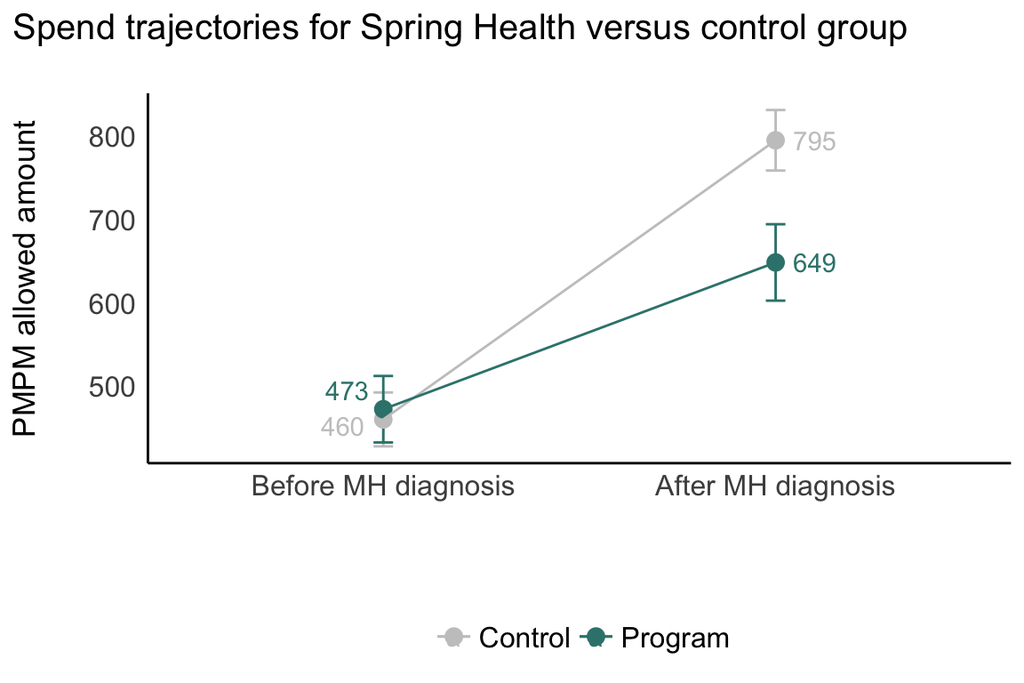

```r
df_plot <- df_matched %>%
  ungroup() %>%
  distinct(spring_dummy, phase) %>%
  mutate(
    phase_label = case_when(
      phase == "pre_tx" ~ "Before MH diagnosis",
      phase == "post_tx" ~ "After MH diagnosis"
    )
  ) %>%
  mutate(phase_label = factor(phase_label, levels = c("Before MH diagnosis", "After MH diagnosis")))

df_plot_total <- predictions(m1_net, newdata = df_plot, re.form = ~0)
df_plot_mh <- predictions(m1_mh, newdata = df_plot, re.form = ~0)
df_plot_nonmh <- predictions(m1_nonmh, newdata = df_plot, re.form = ~0)

color_scheme <- c('#c7c7c7', "#37837c")

# Overall with error bars
ggplot(df_plot_total, aes(x=phase_label, y=estimate, ymin=conf.low, ymax=conf.high, group = spring_dummy, color = spring_dummy)) +
  geom_errorbar(width = 0.05) +
  geom_point(size=3) +
  geom_line() +
  scale_color_manual(values = color_scheme, labels = c("Control", "Program")) +
  geom_text_repel(aes(label=round(estimate, 0)), hjust = ifelse(df_plot$phase_label == "Before MH diagnosis", 1.4, -0.4)) +
  theme_modern() +
  theme(legend.position = "bottom") +
  labs(
    title = "Spend trajectories for Spring Health versus control group",
    x = "",
    y = "PMPM allowed amount",
    color = ""
  )
```

## 5.3 Pharmacy spend models

```r
# Only run rx models if client has rx data
## No matching
m1_rx_no_match <- lmer(rx_pmpm_trunc ~ 1 + spring_dummy + spring_dummy*phase + customer_name +
             (1 | carrier_member_id),
           data = filter(df_analyze_all, index_date >= spring_start_date))

## Matching
m1_rx_yes_match <- lmer(rx_pmpm_trunc ~ 1 + spring_dummy + spring_dummy*phase + customer_name +
             (1 | carrier_member_id) +
             (1 | subclass_nn),
           weights = weights_nn,
           data = df_matched)

tab_model(m1_rx_no_match, m1_rx_yes_match, show.ci=F, show.se=T,
          pred.labels = c("Baseline PMPM", "Baseline difference (Spring - Control)", "Control pre-post change", "Diff-in-diff (Spring change - Control change)"),
          dv.labels = c("Umatched", "Matched"),
          title = "Spring effect on gross pharmacy spending")
```

Spring effect on gross pharmacy spending

|  | Umatched |  |  | Matched |  |  |
| --- | --- | --- | --- | --- | --- | --- |
| Predictors | Estimates | std. Error | p | Estimates | std. Error | p |
| (Intercept) | 191.95 | 30.45 | **<0.001** | 89.83 | 33.81 | **0.008** |
| spring_dummySpring | -27.03 | 15.54 | 0.082 | 10.34 | 13.29 | 0.437 |
| phasepost_tx | 43.58 | 2.49 | **<0.001** | 45.36 | 3.97 | **<0.001** |
| customer_nameHearst | -201.33 | 36.34 | **<0.001** | -108.57 | 42.19 | **0.010** |
| customer_nameIDEXX | 4.58 | 36.32 | 0.900 | 76.81 | 41.10 | 0.062 |
| customer_namePepsi | -28.18 | 30.92 | 0.362 | 45.91 | 35.89 | 0.201 |
| customer_nameTegna | -199.39 | 38.65 | **<0.001** | -107.69 | 43.26 | **0.013** |
| customer_nameWellstar | 56.78 | 33.31 | 0.088 | 97.73 | 38.23 | **0.011** |
| customer_nameWestern Governors University | -1.50 | 36.16 | 0.967 | 50.07 | 39.59 | 0.206 |
| spring_dummySpring:phasepost_tx | -8.01 | 7.33 | 0.275 | -9.23 | 6.73 | 0.170 |
| Random Effects |  |  |  |  |  |  |
| σ<sup>2</sup> | 941456.73 |  |  | 582770.97 |  |  |
| τ<sub>00</sub> | 902654.73 <sub>carrier_member_id</sub> |  |  | 508036.94 <sub>carrier_member_id</sub> |  |  |
|  |  |  |  | 106730.14 <sub>subclass_nn</sub> |  |  |
| ICC | 0.49 |  |  | 0.51 |  |  |
| N | 40158 <sub>carrier_member_id</sub> |  |  | 13971 <sub>carrier_member_id</sub> |  |  |
|  |  |  |  | 4908 <sub>subclass_nn</sub> |  |  |
| Observations | 764663 |  |  | 257007 |  |  |
| Marginal R<sup>2</sup> / Conditional R<sup>2</sup> | 0.002 / 0.491 |  |  | 0.004 / 0.515 |  |  |

```r
# Sensitivity: heavy truncation
df_matched <- df_matched %>%
  mutate(
     rx_pmpm_trunc10k = ifelse(rx_pmpm_trunc > 10000, 10000, rx_pmpm_trunc),
     rx_pmpm_trunc5k = ifelse(rx_pmpm_trunc > 5000, 5000, rx_pmpm_trunc),
     rx_pmpm_trunc2.5k = ifelse(rx_pmpm_trunc > 2500, 2500, rx_pmpm_trunc)
    )

m1_rx_truncate10k <- lmer(rx_pmpm_trunc10k ~ 1 + spring_dummy + spring_dummy*phase + customer_name +
             (1 | carrier_member_id) +
             (1 | subclass_nn),
           weights = weights_nn,
           data = df_matched)

m1_rx_truncate5k <- lmer(rx_pmpm_trunc5k ~ 1 + spring_dummy + spring_dummy*phase + customer_name +
             (1 | carrier_member_id) +
             (1 | subclass_nn),
           weights = weights_nn,
           data = df_matched)

m1_rx_truncate2.5k <- lmer(rx_pmpm_trunc2.5k ~ 1 + spring_dummy + spring_dummy*phase + customer_name +
             (1 | carrier_member_id) +
             (1 | subclass_nn),
           weights = weights_nn,
           data = df_matched)

tab_model(m1_rx_yes_match, m1_rx_truncate10k, m1_rx_truncate5k, m1_rx_truncate2.5k, show.ci=F, show.se=T,
          pred.labels = c("Baseline PMPM", "Baseline difference (Spring - Control)", "Control pre-post change", "Diff-in-diff (Spring change - Control change)"),
          dv.labels = c("Matched - Standard truncation", "Any baseline pharm spend", "Truncate 10k", "Truncate 5k", "Truncate 2.5k"),
          title = "Spring effect on gross pharmacy spending")
```

Spring effect on gross pharmacy spending

[output not shown]

# 6 High cost conditions

## 6.1 High cost conditions models

```r
df_matched <- df_matched %>%
  mutate(cc_any = case_when(
    cc_any == "yes" ~ "yes",
    excl_pregnancy == "yes" ~ "yes",
    TRUE ~ cc_any
  ))


## Model
hcc1 <- lmer(med_pmpm_trunc_net ~ 1 + spring_dummy + spring_dummy*phase +
             cc_any + cc_any*(spring_dummy + spring_dummy*phase) +
             customer_name +
             (1 | carrier_member_id) +
             (1 | subclass_nn),
           weights = weights_nn,
           data = filter(df_matched, cc_any == "no" | cc_diabetes == "yes"))

hcc2 <- lmer(med_pmpm_trunc_net ~ 1 + spring_dummy + spring_dummy*phase +
             cc_any + cc_any*(spring_dummy + spring_dummy*phase) +
             customer_name +
             (1 | carrier_member_id) +
             (1 | subclass_nn),
           weights = weights_nn,
           data = filter(df_matched, cc_any == "no" | cc_hypertension == "yes"))

hcc3 <- lmer(med_pmpm_trunc_net ~ 1 + spring_dummy + spring_dummy*phase +
             cc_any + cc_any*(spring_dummy + spring_dummy*phase) +
             customer_name +
             (1 | carrier_member_id) +
             (1 | subclass_nn),
           weights = weights_nn,
           data = filter(df_matched, cc_any == "no" | cc_asthma_copd == "yes"))

hcc4 <- lmer(med_pmpm_trunc_net ~ 1 + spring_dummy + spring_dummy*phase +
             cc_any + cc_any*(spring_dummy + spring_dummy*phase) +
             customer_name +
             (1 | carrier_member_id) +
             (1 | subclass_nn),
           weights = weights_nn,
           data = filter(df_matched, cc_any == "no" | excl_pregnancy == "yes"))

hcc5 <- lmer(med_pmpm_trunc_net ~ 1 + spring_dummy + spring_dummy*phase +
             cc_any + cc_any*(spring_dummy + spring_dummy*phase) +
             customer_name +
             (1 | carrier_member_id) +
             (1 | subclass_nn),
           weights = weights_nn,
           data = filter(df_matched, cc_any == "no" | cc_cancer == "yes"))

m_no_hcc <- lmer(med_pmpm_trunc_net ~ 1 + spring_dummy + spring_dummy*phase +
             cc_any + cc_any*(spring_dummy + spring_dummy*phase) +
             customer_name +
             (1 | carrier_member_id) +
             (1 | subclass_nn),
           weights = weights_nn,
           data = df_matched)

tab_model(hcc1, hcc2, hcc3, hcc4, hcc5, m_no_hcc,
          dv.labels = c("Diabetes", "Hypertension", "Asthma/COPD", "Pregnancy", "Cancer", "Any HCC"),
          show.ci=F,
          show.se=T)
```

|  | Diabetes |  |  | Hypertension |  |  | Asthma/COPD |  |  | Pregnancy |  |  | Cancer |  |  | Any HCC |  |  |
| --- | --- | --- | --- | --- | --- | --- | --- | --- | --- | --- | --- | --- | --- | --- | --- | --- | --- | --- |
| Predictors | Estimates | std. Error | p | Estimates | std. Error | p | Estimates | std. Error | p | Estimates | std. Error | p | Estimates | std. Error | p | Estimates | std. Error | p |
| (Intercept) | 244.26 | 61.63 | **<0.001** | 229.46 | 59.96 | **<0.001** | 226.06 | 46.01 | **<0.001** | 255.14 | 35.69 | **<0.001** | 281.57 | 63.94 | **<0.001** | 264.70 | 57.68 | **<0.001** |
| spring dummy [Spring] | 13.43 | 19.90 | 0.500 | 9.95 | 25.30 | 0.694 | 9.52 | 19.83 | 0.631 | 4.86 | 17.27 | 0.778 | 11.96 | 22.09 | 0.588 | 11.64 | 27.51 | 0.672 |
| phase [post_tx] | 241.24 | 15.13 | **<0.001** | 241.82 | 18.43 | **<0.001** | 241.01 | 15.54 | **<0.001** | 240.24 | 14.65 | **<0.001** | 241.55 | 16.70 | **<0.001** | 242.06 | 20.00 | **<0.001** |
| cc any [yes] | 575.50 | 50.32 | **<0.001** | 402.03 | 33.36 | **<0.001** | 470.67 | 39.23 | **<0.001** | 753.27 | 42.89 | **<0.001** | 1611.09 | 72.69 | **<0.001** | 443.12 | 30.01 | **<0.001** |
| customer name [Hearst] | 125.41 | 77.82 | 0.107 | 68.23 | 74.51 | 0.360 | 47.82 | 57.75 | 0.408 | 9.57 | 44.92 | 0.831 | 76.52 | 80.86 | 0.344 | 46.71 | 71.21 | 0.512 |
| customer name [IDEXX] | 44.96 | 75.47 | 0.551 | 84.91 | 72.44 | 0.241 | 43.18 | 55.81 | 0.439 | 84.76 | 43.42 | 0.051 | 31.77 | 78.53 | 0.686 | 24.70 | 69.14 | 0.721 |
| customer name [Pepsi] | 28.31 | 66.07 | 0.668 | 71.85 | 63.57 | 0.258 | 46.41 | 48.99 | 0.343 | 9.58 | 37.88 | 0.800 | -16.09 | 68.61 | 0.815 | 18.21 | 60.62 | 0.764 |
| customer name [Tegna] | -66.51 | 79.56 | 0.403 | -76.07 | 76.22 | 0.318 | -59.72 | 59.20 | 0.313 | -68.77 | 45.96 | 0.135 | -135.70 | 82.68 | 0.101 | -123.89 | 72.93 | 0.089 |
| customer name [Wellstar] | 133.03 | 71.23 | 0.062 | 167.54 | 67.99 | **0.014** | 177.45 | 53.05 | **0.001** | 105.65 | 41.16 | **0.010** | 104.65 | 74.49 | 0.160 | 117.36 | 64.65 | 0.069 |
| customer name [Western Governors University] | 54.92 | 72.71 | 0.450 | 92.47 | 69.82 | 0.185 | 104.07 | 53.89 | 0.053 | 6.56 | 42.25 | 0.877 | 74.98 | 75.86 | 0.323 | 80.71 | 66.37 | 0.224 |
| spring dummy [Spring] × phase [post_tx] | -41.06 | 25.00 | 0.101 | -40.52 | 30.49 | 0.184 | -40.36 | 25.70 | 0.116 | -40.56 | 24.22 | 0.094 | -41.50 | 27.60 | 0.133 | -41.62 | 33.11 | 0.209 |
| spring dummy [Spring] × cc any [yes] | -67.53 | 74.17 | 0.363 | 145.64 | 57.66 | **0.012** | 130.04 | 60.59 | **0.032** | 197.47 | 67.49 | **0.003** | -718.42 | 124.69 | **<0.001** | 57.70 | 49.04 | 0.239 |
| phase [post_tx] × cc any [yes] | 344.36 | 49.88 | **<0.001** | 314.32 | 35.88 | **<0.001** | 252.26 | 44.45 | **<0.001** | -44.24 | 55.27 | 0.423 | 915.52 | 73.93 | **<0.001** | 240.44 | 32.68 | **<0.001** |
| (spring dummy [Spring] × phase [post_tx]) × cc any [yes] | -298.48 | 85.10 | **<0.001** | -405.36 | 64.70 | **<0.001** | -301.81 | 73.48 | **<0.001** | -361.45 | 90.52 | **<0.001** | -1014.62 | 133.46 | **<0.001** | -321.35 | 56.34 | **<0.001** |
| Random Effects |  |  |  |  |  |  |  |  |  |  |  |  |  |  |  |  |  |  |
| σ<sup>2</sup> | 5374926.93 |  |  | 7981412.43 |  |  | 5697466.09 |  |  | 5100117.62 |  |  | 6549841.61 |  |  | 9411467.80 |  |  |
| τ<sub>00</sub> | 291991.99 <sub>carrier_member_id</sub> |  |  | 580607.50 <sub>carrier_member_id</sub> |  |  | 285650.42 <sub>carrier_member_id</sub> |  |  | 158419.28 <sub>carrier_member_id</sub> |  |  | 372675.93 <sub>carrier_member_id</sub> |  |  | 707133.94 <sub>carrier_member_id</sub> |  |  |
|  | 704113.39 <sub>subclass_nn</sub> |  |  | 485316.32 <sub>subclass_nn</sub> |  |  | 281092.95 <sub>subclass_nn</sub> |  |  | 130866.88 <sub>subclass_nn</sub> |  |  | 703888.66 <sub>subclass_nn</sub> |  |  | 414952.25 <sub>subclass_nn</sub> |  |  |
| ICC | 0.16 |  |  | 0.12 |  |  | 0.09 |  |  | 0.05 |  |  | 0.14 |  |  | 0.11 |  |  |
| N | 9981 <sub>carrier_member_id</sub> |  |  | 11908 <sub>carrier_member_id</sub> |  |  | 10298 <sub>carrier_member_id</sub> |  |  | 9795 <sub>carrier_member_id</sub> |  |  | 9526 <sub>carrier_member_id</sub> |  |  | 13971 <sub>carrier_member_id</sub> |  |  |
|  | 4607 <sub>subclass_nn</sub> |  |  | 4784 <sub>subclass_nn</sub> |  |  | 4654 <sub>subclass_nn</sub> |  |  | 4419 <sub>subclass_nn</sub> |  |  | 4421 <sub>subclass_nn</sub> |  |  | 4908 <sub>subclass_nn</sub> |  |  |
| Observations | 181795 |  |  | 218223 |  |  | 187831 |  |  | 178267 |  |  | 173450 |  |  | 256996 |  |  |
| Marginal R<sup>2</sup> / Conditional R<sup>2</sup> | 0.009 / 0.164 |  |  | 0.009 / 0.126 |  |  | 0.009 / 0.099 |  |  | 0.010 / 0.063 |  |  | 0.020 / 0.158 |  |  | 0.009 / 0.114 |  |  |

### 6.1.1 Plot by high cost condition

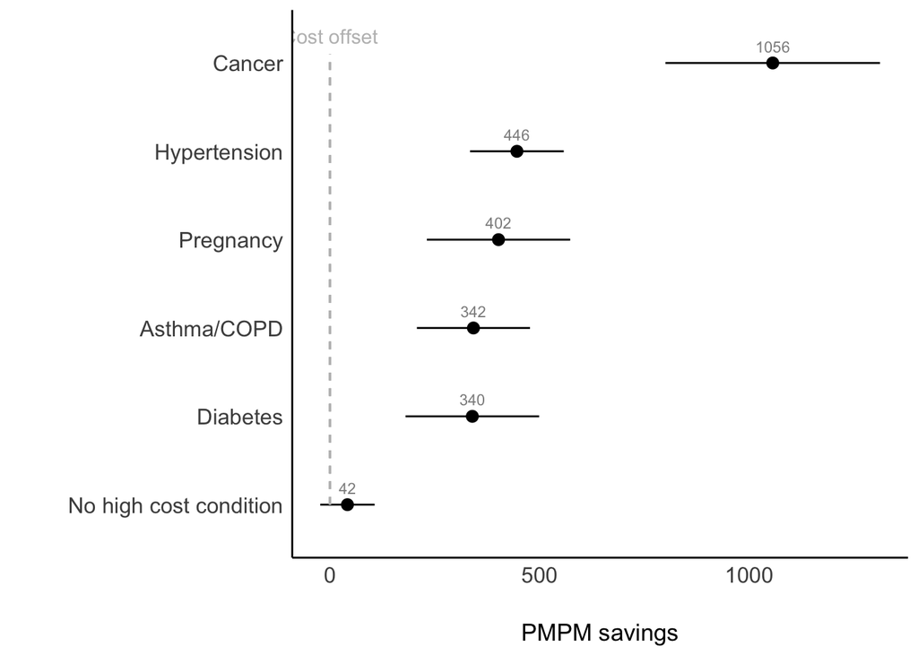

```r
# Make plotting df
m_list <- list(hcc1, hcc2, hcc3, hcc4, hcc5)
df_cc_results <- data.frame(
  Term = NA,
  Estimate = NA,
  se = NA,
  z = NA,
  p = NA,
  lb = NA,
  ub = NA)

for (i in 1:length(m_list)) {
  df_cc_results[i,] <- hypotheses(m_list[[i]], hypothesis = "b11 + b14 = 0")
  df_cc_results[length(m_list) + 1,] <- hypotheses(m_no_hcc, hypothesis = "b11 = 0")
}

# Add cc names
df_cc_results <- df_cc_results %>%
  mutate(
    hcc = c("Diabetes", "Hypertension", "Asthma/COPD", "Pregnancy", "Cancer", "No high cost condition"),
    var_name = c("cc_diabetes", "cc_hypertension", "cc_asthma_copd", "excl_pregnancy", "cc_cancer", "No high cost condition")
  )

## Make it nice
df_plot_hcc <- df_cc_results %>%
  mutate(
    Estimate = -1*Estimate,
    lb = -1*lb,
    ub = -1*ub
  ) %>%
  mutate(hcc = fct_reorder(as.factor(hcc), Estimate))


# Make dotplot
ggplot(df_plot_hcc, aes(x=Estimate, xmin=lb, xmax=ub, y=hcc)) +
  geom_pointrange(position = position_dodge(width=0.5)) +
  geom_text(aes(x=Estimate, y=hcc, label = round(Estimate, 0), fill = NULL, vjust = -1), colour = "#8e8e8e", size = 3) +
  geom_segment(x = 0, xend=0, y=1, yend = 6.1, linetype = "dashed", color = "grey") +
  annotate(geom = "text", x=0, y=6.3, label = "Cost offset", hjust=0.5, color = "grey") +
  expand_limits(y = c(1, 6.5)) +
  theme_modern() +
  theme(legend.position = "bottom") +
  labs(
    x = "PMPM savings",
    y = "",
    fill = " "
  )
```

## 6.2 Service categories

```r
# Mental health vs Physical health
m1_mh <- lmer(med_pmpm_trunc_mh_net ~ 1 + spring_dummy + spring_dummy*phase +
                (1 | carrier_member_id) +
                (1 | subclass_nn),
              weights = weights_nn,
              data = df_matched)

m1_nonmh <- lmer(med_pmpm_trunc_nonmh ~ 1 + spring_dummy + spring_dummy*phase +
                   (1 | carrier_member_id) +
                   (1 | subclass_nn),
                 weights = weights_nn,
                 data = df_matched)

# By category

cc1 <- lmer(med_pmpm_trunc_ov_mh ~ 1 + spring_dummy + spring_dummy*phase +
              (1 | carrier_member_id) +
              (1 | subclass_nn),
            weights = weights_nn,
            data = df_matched)

cc2 <- lmer(med_pmpm_trunc_er_mh ~ 1 + spring_dummy + spring_dummy*phase +
              (1 | carrier_member_id) +
              (1 | subclass_nn),
            weights = weights_nn,
            data = df_matched)

cc3 <- lmer(med_pmpm_trunc_hosp_op_mh ~ 1 + spring_dummy + spring_dummy*phase +
              (1 | carrier_member_id) +
              (1 | subclass_nn),
            weights = weights_nn,
            data = df_matched)

cc4 <- lmer(med_pmpm_trunc_ip_mh ~ 1 + spring_dummy + spring_dummy*phase +
              (1 | carrier_member_id) +
              (1 | subclass_nn),
            weights = weights_nn,
            data = df_matched)

cc5 <- lmer(med_pmpm_trunc_therapy_mh_net ~ 1 + spring_dummy + spring_dummy*phase +
              (1 | carrier_member_id) +
              (1 | subclass_nn),
            weights = weights_nn,
            data = df_matched)

## Non-MH
cc6 <- lmer(med_pmpm_trunc_ov_nonmh ~ 1 + spring_dummy + spring_dummy*phase +
              (1 | carrier_member_id) +
              (1 | subclass_nn),
            weights = weights_nn,
            data = df_matched)

cc7 <- lmer(med_pmpm_trunc_er_nonmh ~ 1 + spring_dummy + spring_dummy*phase +
              (1 | carrier_member_id) +
              (1 | subclass_nn),
            weights = weights_nn,
            data = df_matched)

cc8 <- lmer(med_pmpm_trunc_hosp_op_nonmh ~ 1 + spring_dummy + spring_dummy*phase +
              (1 | carrier_member_id) +
              (1 | subclass_nn),
            weights = weights_nn,
            data = df_matched)

cc9 <- lmer(med_pmpm_trunc_ip_nonmh ~ 1 + spring_dummy + spring_dummy*phase +
              (1 | carrier_member_id) +
              (1 | subclass_nn),
            weights = weights_nn,
            data = df_matched)

cc10 <- lmer(med_pmpm_trunc_therapy_nonmh ~ 1 + spring_dummy + spring_dummy*phase +
               (1 | carrier_member_id) +
               (1 | subclass_nn),
             weights = weights_nn,
             data = df_matched)

spend_cat <- rep(c("Office visits", "Emergency room", "Hospital outpatient", "Hospital inpatient", "Behavioral Health"), 2)
mh_spend <- c(rep("Mental health", 5), rep("Physical health", 5))
df_cc_list <- list()

for (i in 1:10) {
  df_temp <- predictions(get(paste0("cc", i)), newdata = df_plot, re.form = ~0) %>%
    mutate(
      spend_category = spend_cat[i],
      mh = mh_spend[i]
      )
  df_cc_list[[i]] <- df_temp
}
```

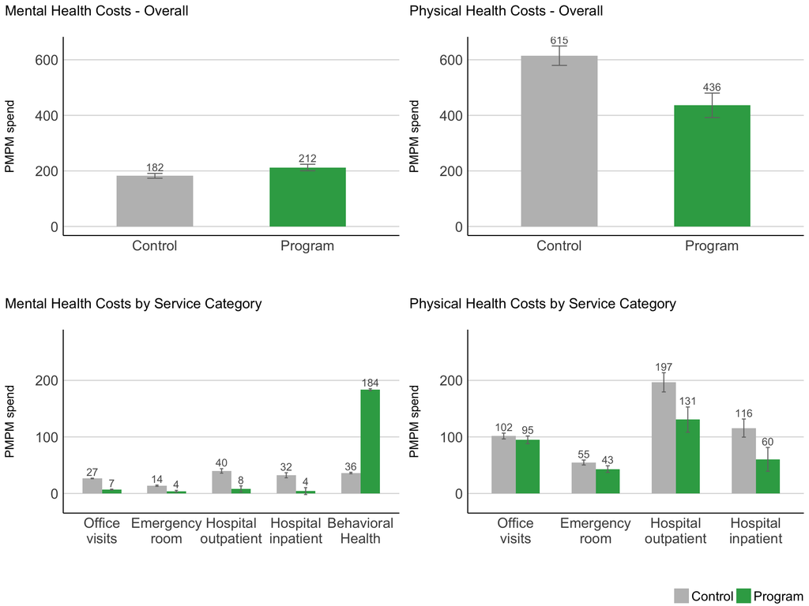

```r
df_cc_plot <- df_cc_list %>%
  bind_rows() %>%
  filter(phase == "post_tx") %>%
  select(spring_dummy, spend_category, mh, estimate, conf.low, conf.high) %>%
  mutate(spring_dummy = factor(spring_dummy, levels = c("Health Plan", "Spring"))) %>%
  mutate(spend_category = factor(spend_category, levels = c("Office visits", "Emergency room", "Hospital outpatient", "Hospital inpatient", "Behavioral Health")))


# Aesthetics
y_total <- 650 # total axis scale
y_cat <- 275 # category axis scale
cc_colors <- c("#34a853", "grey")

# Overall MH
df_plot_mh <- predictions(m1_mh, newdata = df_plot, re.form = ~0) %>%
  mutate(spend_category = "Mental Health - Overall") %>%
  filter(phase == "post_tx") %>%
  mutate(spring_dummy = ifelse(spring_dummy == "Spring", "Program", "Control"))

p1 <- ggplot(df_plot_mh, aes(x=spring_dummy, y=estimate, ymin = conf.low, ymax = conf.high, fill = spring_dummy, group = spring_dummy)) +
  geom_bar(stat = "identity", width = 0.5) +
  geom_errorbar(width = .1, color = "gray45") +
  scale_fill_manual(values = rev(cc_colors), labels = c("Control", "Program")) +
  geom_text(aes(x=spring_dummy, y=conf.high, label = round(estimate, 0), fill = NULL), colour = "gray35", size = 4, vjust=-0.3) +
  scale_y_continuous(breaks = seq(0, y_total, by = 200), limits = c(0, y_total)) +
  theme_modern() +
  theme(panel.grid.major.y = element_line(color = "gray85")) +
  theme(axis.text.x = element_text(size=15)) +
  theme(axis.text.y = element_text(size=15)) +
  theme(axis.title.x = element_text(size=18)) +
  theme(legend.text =  element_text(size=14)) +
  theme(
    legend.position = "none",
    legend.justification = "right",
    strip.text = element_text(size=15)
  ) +
  labs(
    title = "Mental Health Costs - Overall",
    x = "",
    y = "PMPM spend",
    fill = " "
  )
fig_legend <- get_legend(p1 + theme(legend.position = "bottom"))

# Overall PH
df_plot_nonmh <- predictions(m1_nonmh, newdata = df_plot, re.form = ~0) %>%
  filter(phase == "post_tx") %>%
  mutate(spend_category = "Physical Health - Overall") %>%
  mutate(spring_dummy = ifelse(spring_dummy == "Spring", "Program", "Control"))

p2 <- ggplot(df_plot_nonmh, aes(x=spring_dummy, y=estimate, ymin = conf.low, ymax = conf.high, fill = spring_dummy, group = spring_dummy)) +
  geom_bar(stat = "identity", width = 0.5) +
  geom_errorbar(width = .1, color = "gray45") +
  scale_fill_manual(values = rev(cc_colors), labels = c("Control", "Program")) +
  geom_text(aes(x=spring_dummy, y=conf.high, label = round(estimate, 0), fill = NULL), colour = "gray35", size = 4, vjust=-0.3) +
  scale_y_continuous(breaks = seq(0, y_total, by = 200), limits = c(0, y_total)) +
  theme_modern() +
  theme(panel.grid.major.y = element_line(color = "gray85")) +
  theme(axis.text.x = element_text(size=15)) +
  theme(axis.text.y = element_text(size=15)) +
  theme(axis.title.x = element_text(size=18)) +
  theme(legend.text =  element_text(size=14)) +
  theme(
    legend.position = "none",
    legend.justification = "right",
    strip.text = element_text(size=15)
  ) +
  labs(
    title = "Physical Health Costs - Overall",
    x = "",
    y = "PMPM spend",
    fill = " "
  )


# MH breakdown
p3 <- ggplot(filter(df_cc_plot, mh == "Mental health"), aes(x=spend_category, y=estimate, ymin = conf.low, ymax = conf.high, fill = spring_dummy, group = spring_dummy)) +
  geom_bar(stat = "identity", width = 0.6, position = position_dodge()) +
  geom_errorbar(position = position_dodge(0.6), width = .1, color = "gray45") +
  scale_fill_manual(values = rev(cc_colors), labels = c("Control", "Program")) +
  geom_text(aes(x=spend_category, y=conf.high, label = round(estimate, 0), fill = NULL), colour = "gray35", size = 4, vjust=-0.3, position = position_dodge(width = 0.6)) +
  scale_x_discrete(labels = scales::label_wrap(10)) +
  scale_y_continuous(breaks = seq(0, y_cat, by = 100), limits = c(-20, 275)) +
  theme_modern() +
  theme(panel.grid.major.y = element_line(color = "gray85")) +
  theme(axis.text.x = element_text(size=15)) +
  theme(axis.text.y = element_text(size=15)) +
  theme(axis.title.x = element_text(size=18)) +
  theme(legend.text =  element_text(size=14)) +
  theme(
    legend.position = "none",
    legend.justification = "right",
    strip.text = element_text(size=15)
  ) +
  labs(
    title = "Mental Health Costs by Service Category",
    x = "",
    y = "PMPM spend",
    fill = " "
  )


# PH breakdown
p4 <- ggplot(filter(df_cc_plot, mh == "Physical health" & spend_category != "Behavioral Health"), aes(x=spend_category, y=estimate, ymin = conf.low, ymax = conf.high, fill = spring_dummy, group = spring_dummy)) +
  geom_bar(stat = "identity", width = 0.6, position = position_dodge()) +
  geom_errorbar(position = position_dodge(0.6), width = .1, color = "gray45") +
  scale_fill_manual(values = rev(cc_colors), labels = c("Control", "Program")) +
  geom_text(aes(x=spend_category, y=conf.high, label = round(estimate, 0), fill = NULL), colour = "gray35", size = 4, vjust=-0.3, position = position_dodge(width = 0.6)) +
  scale_x_discrete(labels = scales::label_wrap(10)) +
  scale_y_continuous(breaks = seq(0, y_cat, by = 100), limits = c(-20, 275)) +
  theme_modern() +
  theme(panel.grid.major.y = element_line(color = "gray85")) +
  theme(axis.text.x = element_text(size=15)) +
  theme(axis.text.y = element_text(size=15)) +
  theme(axis.title.x = element_text(size=18)) +
  theme(legend.text =  element_text(size=14)) +
  theme(
    legend.position = "none",
    legend.justification = "right",
    strip.text = element_text(size=15)
  ) +
  labs(
    title = "Physical Health Costs by Service Category",
    x = "",
    y = "PMPM spend",
    fill = " "
  )

cowplot::plot_grid(p1, p2, p3, p4, NA, fig_legend, nrow=3, rel_heights = c(1,1,.07))
```

## 6.3 Therapy moderators

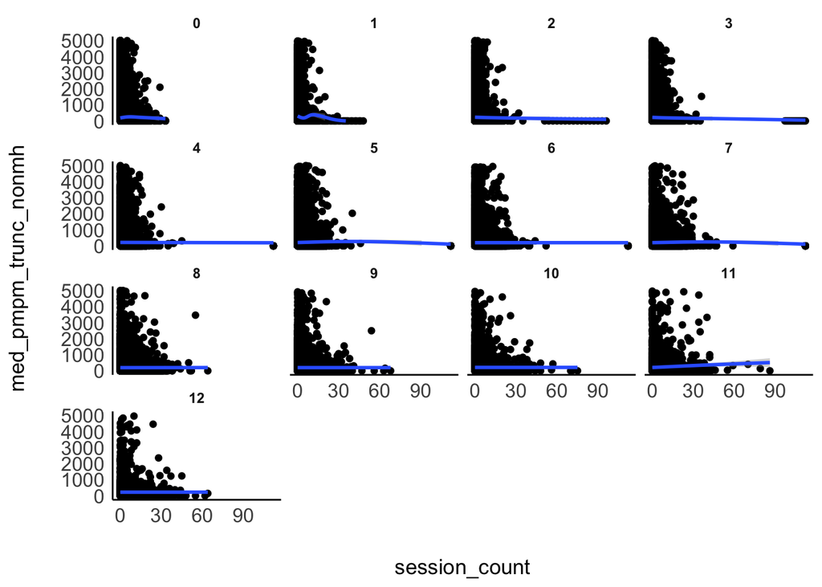

```r
# Calculate cumulative sessions
df_matched <- df_matched %>%
  group_by(carrier_member_id) %>%
  arrange(months) %>%
  mutate(
    session_count = case_when(
      spring_dummy == "Spring" ~ cumsum(spring_tx_count_month),
      spring_dummy == "Health Plan" ~ cumsum(carrier_tx_count_month)
    )
  ) %>%
  mutate(session_count_trunc = ifelse(session_count > 24, 24, session_count)) %>%
  mutate(session_count_total = max(session_count, na.rm=T))

# Let's look at non-mh spending only, since otherwise spending is complicated by spring spend not being included
ggplot(df_matched, aes(x=session_count, y = med_pmpm_trunc_nonmh)) +
  geom_point() +
  geom_smooth() +
  facet_wrap(.~ months_post) +
  theme_modern() +
  ylim(0, 5000)
```

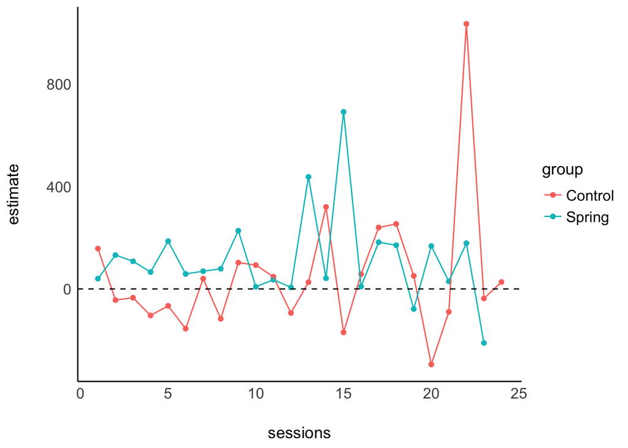

```r
# Allow some nonlinearity
df_matched <- df_matched %>%
  mutate(
    therapy_sessions_factor = case_when(
      session_count == 0 ~ "0",
      session_count > 0 & session_count <= 2 ~ "1 to 2",
      session_count > 2 & session_count <= 5 ~ "3 to 5",
      session_count > 5 & session_count <= 12 ~ "6 to 12",
      session_count > 12 ~ "13+"
    ),
    any_therapy = ifelse(session_count > 0, "yes", "no")
  ) %>%
  mutate(therapy_sessions_factor = factor(therapy_sessions_factor, levels = c("0", "1 to 2", "3 to 5", "6 to 12", "13+")))

m_sessions0 <- lmer(med_pmpm_trunc_nonmh ~ 0 + spring_dummy:phase + spring_dummy:as.factor(session_count_trunc) + as.factor(months_post):spring_dummy +
             (1 | carrier_member_id) +
             (1 | subclass_nn),
           weights = weights_nn,
           data = filter(df_matched))

m_sessions_numeric <- lmer(med_pmpm_trunc_nonmh ~ 0 + spring_dummy:phase + spring_dummy:session_count_trunc + as.factor(months_post):spring_dummy +
             (1 | carrier_member_id) +
             (1 | subclass_nn),
           weights = weights_nn,
           data = filter(df_matched))

df_sessions <- m_sessions0 %>%
  broom.mixed::tidy() %>%
  filter(str_detect(term, "session_count")) %>%
  #mutate(term = str_replace(term, "spring_dummy", "")) %>%
  mutate(group = ifelse(str_detect(term, "Health Plan"), "Control", "Spring")) %>%
  mutate(sessions = str_extract(term,  "\\)(.*)")) %>%
  mutate(sessions = str_replace(sessions, "\\)", "")) %>%
  mutate(sessions = as.numeric(sessions))

ggplot(df_sessions, aes(x=sessions, y=estimate, group=group, color=group)) +
  geom_point() +
  geom_line() +
  geom_hline(yintercept = 0, linetype = "dashed") +
  theme_modern()
```

```r
m_sessions1 <- lmer(med_pmpm_trunc_nonmh ~ 1 + spring_dummy + spring_dummy*phase +
                     as.factor(months_post) + as.factor(months_post)*spring_dummy +
                      any_therapy + session_count + session_count*spring_dummy +
             (1 | carrier_member_id) +
             (1 | subclass_nn),
           weights = weights_nn,
           data = df_matched)

m_sessions2 <- lmer(med_pmpm_trunc_nonmh ~ 1 + spring_dummy + spring_dummy*phase +
                     as.factor(months_post) + as.factor(months_post)*spring_dummy +
                      therapy_sessions_factor + therapy_sessions_factor*spring_dummy +
             (1 | carrier_member_id) +
             (1 | subclass_nn),
           weights = weights_nn,
           data = df_matched)

m_sessions3 <- lmer(med_pmpm_trunc_nonmh ~ 1 + spring_dummy + spring_dummy*phase +
                     as.factor(months_post) + as.factor(months_post)*spring_dummy +
                      therapy_sessions_factor +
             (1 | carrier_member_id) +
             (1 | subclass_nn),
           weights = weights_nn,
           data = df_matched)

tab_model(m_sessions1, m_sessions2,
          drop = c("months_post", "(Intercept)", "phase"),
          show.ci=F,
          show.icc = F,
          show.re.var = F,
          show.r2 = F,
          show.aic = T,
          dv.labels = c("Model 1", "Model 2"),
          show.se=T)
```

|  | Model 1 |  |  | Model 2 |  |  |
| --- | --- | --- | --- | --- | --- | --- |
| Predictors | Estimates | std. Error | p | Estimates | std. Error | p |
| spring dummy [Spring] | 7.96 | 21.21 | 0.708 | 8.06 | 21.21 | 0.704 |
| any therapy [yes] | 28.47 | 32.10 | 0.375 |  |  |  |
| session count | -0.65 | 3.41 | 0.849 |  |  |  |
| spring dummy [Spring] × session count | 1.84 | 4.52 | 0.684 |  |  |  |
| therapy sessions factor [1 to 2] |  |  |  | 82.57 | 36.04 | **0.022** |
| therapy sessions factor [3 to 5] |  |  |  | -60.14 | 43.85 | 0.170 |
| therapy sessions factor [6 to 12] |  |  |  | -23.21 | 47.36 | 0.624 |
| therapy sessions factor [13+] |  |  |  | 90.06 | 66.49 | 0.176 |
| spring dummy [Spring] × therapy sessions factor [1 to 2] |  |  |  | -132.58 | 123.40 | 0.283 |
| spring dummy [Spring] × therapy sessions factor [3 to 5] |  |  |  | 42.57 | 125.00 | 0.733 |
| spring dummy [Spring] × therapy sessions factor [6 to 12] |  |  |  | -37.38 | 124.40 | 0.764 |
| N | 13971 <sub>carrier_member_id</sub> |  |  | 13971 <sub>carrier_member_id</sub> |  |  |
|  | 4908 <sub>subclass_nn</sub> |  |  | 4908 <sub>subclass_nn</sub> |  |  |
| Observations | 257007 |  |  | 257007 |  |  |
| AIC | 4851594.273 |  |  | 4851538.352 |  |  |

## 6.4 Trajectories

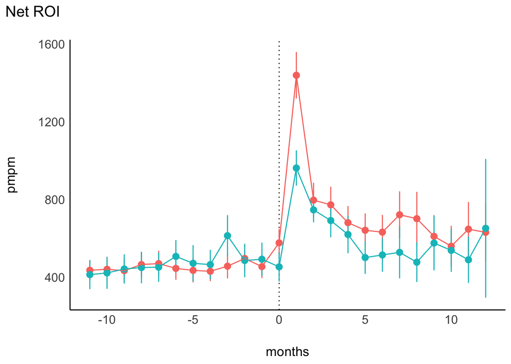

```r
library(splines)

# Fit models
m1_spline <- lmer(med_pmpm_trunc_net ~ 1 + spring_dummy + spring_dummy*phase +
                    spring_dummy*(ns(months_post, df = 4)) +
                    (1 | carrier_member_id) +
                    (1 | subclass_nn),
                  weights = weights_nn,
                  data = df_matched)

df_pred <- df_matched %>%
  distinct(spring_dummy, phase, months, months_post)

  df_plot_splines <- predictions(
    m1_spline,
    newdata = df_pred,
    re.form = ~0)


# Plot raw
df_matched %>%
  group_by(spring_dummy, months) %>%
  summarize(
    pmpm = mean(med_pmpm_trunc_net, na.rm=T),
    sd = sd(med_pmpm_trunc_net, na.rm=T),
    n = n_distinct(carrier_member_id),
    se = sd/sqrt(n)
    ) %>%
  filter(months <= 12) %>%
  ggplot(., aes(x=months, y=pmpm, ymin = pmpm - 1.96*se, ymax = pmpm + 1.96*se, group = spring_dummy, color=spring_dummy)) +
  geom_vline(xintercept = 0, linetype = "dotted") +
  geom_pointrange() +
  geom_line() +
  theme_modern() +
  theme(
    legend.position = "none",
    strip.text.x = element_blank()
    ) +
  labs(title = "Net ROI")
```

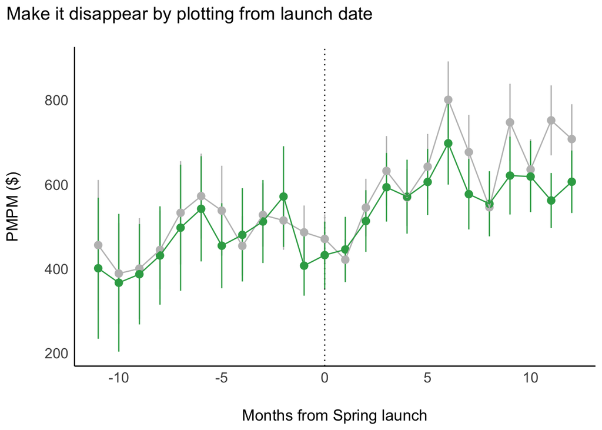

```r
## Make it disappear by plotting from launch date
## Approximate net ROI
df_matched %>%
  mutate(months_from_launch = interval(spring_start_date, month_year) %/% months(1) + 1) %>%
  group_by(spring_dummy, months_from_launch) %>%
  summarize(
    pmpm = mean(med_pmpm_trunc_net, na.rm=T),
    sd = sd(med_pmpm_trunc_net, na.rm=T),
    n = n_distinct(carrier_member_id),
    se = sd/sqrt(n)
    ) %>%
  filter(months_from_launch <= 12) %>%
  ggplot(., aes(x=months_from_launch, y=pmpm, ymin = pmpm - 1.96*se, ymax = pmpm + 1.96*se, group = spring_dummy, color=spring_dummy)) +
  geom_vline(xintercept = 0, linetype = "dotted") +
  geom_pointrange() +
  geom_line() +
  scale_color_manual(values = rev(cc_colors), labels = c("Control", "Spring Health")) +
  theme_modern() +
  theme(
    legend.position = "none",
    strip.text.x = element_blank()
    ) +
  labs(
    x = "Months from Spring launch",
    y = "PMPM ($)",
    title = "Make it disappear by plotting from launch date")
```

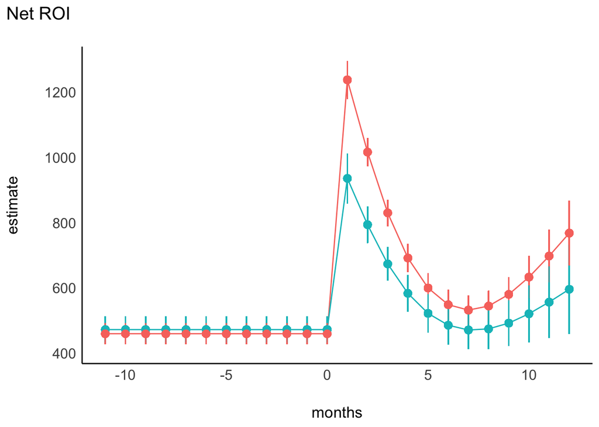

```r
# Plot splines
ggplot(df_plot_splines, aes(x=months, y=estimate, ymin = conf.low, ymax=conf.high, group = spring_dummy, color=spring_dummy)) +
  geom_line() +
  geom_pointrange() +
  theme_modern() +
  theme(
    legend.position = "none",
    strip.text.x = element_blank()
  ) +
    labs(title = "Net ROI")
```

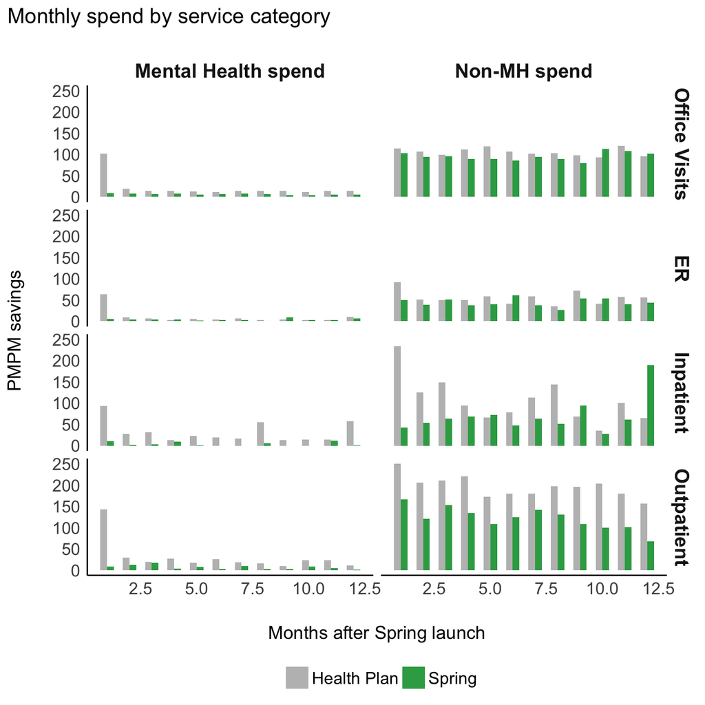

```r
df_monthly_spend <- df_matched %>%
  group_by(spring_dummy, months) %>%
  summarize(
    pmpm_mh_ov = mean(med_pmpm_trunc_ov_mh, na.rm=T),
    pmpm_mh_er = mean(med_pmpm_trunc_er_mh, na.rm=T),
    pmpm_mh_op = mean(med_pmpm_trunc_hosp_op_mh, na.rm=T),
    pmpm_mh_ip = mean(med_pmpm_trunc_ip_mh, na.rm=T),
    pmpm_mh_therapy = mean(med_pmpm_therapy_mh_net),

    pmpm_nonmh_ov = mean(med_pmpm_trunc_ov_nonmh, na.rm=T),
    pmpm_nonmh_er = mean(med_pmpm_trunc_er_nonmh, na.rm=T),
    pmpm_nonmh_op = mean(med_pmpm_trunc_hosp_op_nonmh, na.rm=T),
    pmpm_nonmh_ip = mean(med_pmpm_trunc_ip_nonmh, na.rm=T),
    pmpm_nonmh_therapy = mean(med_pmpm_therapy_nonmh)
    ) %>%
  filter(months <= 12) %>%
  filter(months > 0) %>%
  pivot_longer(
    cols = c(pmpm_mh_ov:pmpm_nonmh_therapy),
    names_prefix = "pmpm_",
    names_to = "spend_cat",
    values_to = "estimate"
    ) %>%
  mutate(
    mh_spend = ifelse(str_starts(spend_cat, "mh_*"), "mh", "non-MH"),
    category = str_replace(spend_cat, ".*_", "")
  ) %>%
  mutate(
    mh_spend = ifelse(mh_spend == "mh", "Mental Health spend", "Non-MH spend"),
    category = case_when(
      category == "er" ~ "ER",
      category == "ip" ~ "Inpatient",
      category == "op" ~ "Outpatient",
      category == "ov" ~ "Office Visits",
      category == "therapy" ~ "Therapy"
    )
  ) %>%
  mutate(category = factor(category, levels = c("Therapy", "Office Visits", "ER", "Inpatient", "Outpatient")))

# Category level
ggplot(filter(df_monthly_spend, category != "Therapy"), aes(x=months, y=estimate, group = spring_dummy, fill = spring_dummy)) +
  geom_bar(stat = "identity", width = 0.6, position=position_dodge()) +
  scale_fill_manual(values = rev(cc_colors)) +
  #geom_text(aes(x=total, y=chronic_condition, label = round(total, 0), fill = NULL, hjust = ifelse(total < 0, 1.1, -0.4)), colour = "#8e8e8e", size = 3, data = df_labels) +
  #expand_limits(x=c(0, 1.1*max(df_labels$total))) +
  theme_modern() +
  facet_grid(rows=vars(category), cols=vars(mh_spend), scales = "fixed") +
  theme(legend.position = "bottom") +
  theme(strip.text = element_text(size = 14)) +
  labs(
    title = "Monthly spend by service category",
    x = "Months after Spring launch",
    y = "PMPM savings",
    fill = " "
  )
```

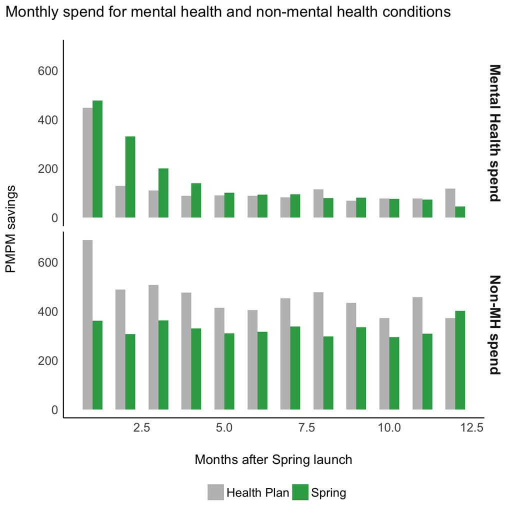

```r
# MH vs non-MH
df_monthly_spend %>%
  group_by(spring_dummy, months, mh_spend) %>%
  summarize(estimate = sum(estimate, na.rm=T)) %>%
  # Plot
  ggplot(., aes(x=months, y=estimate, group = spring_dummy, fill = spring_dummy)) +
  geom_bar(stat = "identity", width = 0.6, position=position_dodge()) +
  scale_fill_manual(values = rev(cc_colors)) +
  #geom_text(aes(x=total, y=chronic_condition, label = round(total, 0), fill = NULL, hjust = ifelse(total < 0, 1.1, -0.4)), colour = "#8e8e8e", size = 3, data = df_labels) +
  #expand_limits(x=c(0, 1.1*max(df_labels$total))) +
  theme_modern() +
  facet_grid(rows=vars(mh_spend), scales = "fixed") +
  theme(legend.position = "bottom") +
  theme(strip.text = element_text(size = 14)) +
  labs(
    title = "Monthly spend for mental health and non-mental health conditions",
    x = "Months after Spring launch",
    y = "PMPM savings",
    fill = " "
  )
```

# 7 ROI

## 7.1 Calculate ROI

- Note: participant-year ROI multiple is too high because it is currently based on incomplete fees.

```r
df_roi <- df_matched %>%
  filter(spring_dummy == "Spring") %>%
  filter(month_year == first_spring_tx_date) %>%
  mutate(months_treated = interval(first_spring_tx_date, spring_end_date) %/% months(1) + 1) %>%
  group_by(months_treated) %>%
  summarize(n = n_distinct(carrier_member_id)) %>%
  mutate(
    member_months_treated = n*months_treated,
    month_roi_gross = -1*n*months_treated*summary(m1_gross)$coefficients["spring_dummySpring:phasepost_tx", 1])
mean_months_treated <- sum(df_roi$member_months_treated)/sum(df_roi$n)


# First program year gross savings %
deltamethod(m1_gross, "0 = (6.5*b4) / ((12-6.5)*df_plot_total$estimate[1] + 6.5*(df_plot_total$estimate[2]))") # (PMPM savings / total control group spend)
```

```
##
##                                                                                   Term
##  0 = (6.5*b4) / ((12-6.5)*df_plot_total$estimate[1] + 6.5*(df_plot_total$estimate[2]))
##  Estimate Std. Error    z Pr(>|z|) 2.5 % 97.5 %
##     0.289     0.0226 12.8   <0.001 0.244  0.333
##
## Columns: term, estimate, std.error, statistic, p.value, conf.low, conf.high
```

```r
# First Program-year PMPY
deltamethod(m1_gross, "0 = -1 * b4 * mean_months_treated")
```

```
##
##                               Term Estimate Std. Error     z Pr(>|z|) 2.5 %
##  0 = -1 * b4 * mean_months_treated    -2228        174 -12.8   <0.001 -2569
##  97.5 %
##   -1886
##
## Columns: term, estimate, std.error, statistic, p.value, conf.low, conf.high
```

```r
# Program-year ROI multiple
deltamethod(m1_net, "0 = (1 + (-1*b4 * sum(df_roi$member_months_treated)) / total_invoiced)")
```

```
##
##                                                                    Term
##  0 = (1 + (-1*b4 * sum(df_roi$member_months_treated)) / total_invoiced)
##  Estimate Std. Error     z Pr(>|z|) 2.5 % 97.5 %
##     -1.85      0.144 -12.9   <0.001 -2.13  -1.57
##
## Columns: term, estimate, std.error, statistic, p.value, conf.low, conf.high
```

# 8 Sensitivity analysis

## 8.1 Do session counts differ for individuals with high cost conditoins?

```r
df_cc_table <- df_match_table %>%
  mutate(cc_group = case_when(
    cc_cancer == "yes" ~ "Cancer",
    cc_hypertension == "yes" ~ "Hypertension",
    excl_pregnancy == "yes" ~ "Pregnancy",
    cc_diabetes == "yes" ~ "Diabetes",
    cc_asthma_copd == "yes" ~ "Asthma/COPD",
    TRUE ~ "No chronic condition"
  ))

table1( ~ age_at_index + member_sex + dx_imputed + risk_score_dx + months_diagnosed + any_bh + bh_if_engaged | spring_dummy*cc_group,
        overall = T,
        footnote = "This table is based on raw values. In cases where 2 matches were not achieved, weights were applied.",
        data=df_cc_table)
```

|  | Control Asthma/COPD (N=481) | Control Cancer (N=284) | Control Diabetes (N=182) | Control Hypertension (N=1857) | Control No chronic condition (N=5883) | Control Pregnancy (N=379) | Spring Health Asthma/COPD (N=282) | Spring Health Cancer (N=129) | Spring Health Diabetes (N=109) | Spring Health Hypertension (N=776) | Spring Health No chronic condition (N=3384) | Spring Health Pregnancy (N=225) | TRUE Asthma/COPD (N=763) | TRUE Cancer (N=413) | TRUE Diabetes (N=291) | TRUE Hypertension (N=2633) | TRUE No chronic condition (N=9267) | TRUE Pregnancy (N=604) |
| --- | --- | --- | --- | --- | --- | --- | --- | --- | --- | --- | --- | --- | --- | --- | --- | --- | --- | --- |
| Age |  |  |  |  |  |  |  |  |  |  |  |  |  |  |  |  |  |  |
| Mean (SD) | 33.0 (14.3) | 50.4 (11.3) | 44.8 (12.6) | 47.7 (10.7) | 33.7 (13.3) | 31.5 (5.12) | 36.2 (11.4) | 48.6 (11.0) | 42.4 (11.5) | 46.1 (10.2) | 35.2 (11.2) | 32.6 (4.75) | 34.2 (13.4) | 49.8 (11.3) | 43.9 (12.2) | 47.2 (10.5) | 34.2 (12.6) | 31.9 (5.01) |
| Median [Min, Max] | 32.0 [5.00, 66.0] | 51.0 [9.00, 75.0] | 47.0 [9.00, 72.0] | 48.0 [12.0, 85.0] | 33.0 [5.00, 74.0] | 32.0 [17.0, 44.0] | 36.0 [6.00, 65.0] | 51.0 [21.0, 73.0] | 42.0 [16.0, 64.0] | 46.0 [19.0, 71.0] | 34.0 [6.00, 74.0] | 33.0 [17.0, 51.0] | 33.0 [5.00, 66.0] | 51.0 [9.00, 75.0] | 45.0 [9.00, 72.0] | 48.0 [12.0, 85.0] | 33.0 [5.00, 74.0] | 32.0 [17.0, 51.0] |
| Sex (assigned at birth) |  |  |  |  |  |  |  |  |  |  |  |  |  |  |  |  |  |  |
| female | 322 (66.9%) | 194 (68.3%) | 117 (64.3%) | 1092 (58.8%) | 3762 (63.9%) | 377 (99.5%) | 197 (69.9%) | 97 (75.2%) | 73 (67.0%) | 494 (63.7%) | 2194 (64.8%) | 225 (100%) | 519 (68.0%) | 291 (70.5%) | 190 (65.3%) | 1586 (60.2%) | 5956 (64.3%) | 602 (99.7%) |
| male | 159 (33.1%) | 90 (31.7%) | 65 (35.7%) | 765 (41.2%) | 2121 (36.1%) | 2 (0.5%) | 85 (30.1%) | 32 (24.8%) | 36 (33.0%) | 282 (36.3%) | 1190 (35.2%) | 0 (0%) | 244 (32.0%) | 122 (29.5%) | 101 (34.7%) | 1047 (39.8%) | 3311 (35.7%) | 2 (0.3%) |
| Mental health diagnosis |  |  |  |  |  |  |  |  |  |  |  |  |  |  |  |  |  |  |
| mood | 100 (20.8%) | 64 (22.5%) | 59 (32.4%) | 445 (24.0%) | 1241 (21.1%) | 73 (19.3%) | 67 (23.8%) | 34 (26.4%) | 25 (22.9%) | 194 (25.0%) | 647 (19.1%) | 50 (22.2%) | 167 (21.9%) | 98 (23.7%) | 84 (28.9%) | 639 (24.3%) | 1888 (20.4%) | 123 (20.4%) |
| anxiety | 352 (73.2%) | 198 (69.7%) | 107 (58.8%) | 1307 (70.4%) | 4271 (72.6%) | 299 (78.9%) | 202 (71.6%) | 89 (69.0%) | 79 (72.5%) | 537 (69.2%) | 2529 (74.7%) | 173 (76.9%) | 554 (72.6%) | 287 (69.5%) | 186 (63.9%) | 1844 (70.0%) | 6800 (73.4%) | 472 (78.1%) |
| sud | 11 (2.3%) | 15 (5.3%) | 7 (3.8%) | 72 (3.9%) | 163 (2.8%) | 2 (0.5%) | 5 (1.8%) | 4 (3.1%) | 3 (2.8%) | 33 (4.3%) | 92 (2.7%) | 1 (0.4%) | 16 (2.1%) | 19 (4.6%) | 10 (3.4%) | 105 (4.0%) | 255 (2.8%) | 3 (0.5%) |
| other | 18 (3.7%) | 7 (2.5%) | 9 (4.9%) | 33 (1.8%) | 208 (3.5%) | 5 (1.3%) | 8 (2.8%) | 2 (1.6%) | 2 (1.8%) | 12 (1.5%) | 116 (3.4%) | 1 (0.4%) | 26 (3.4%) | 9 (2.2%) | 11 (3.8%) | 45 (1.7%) | 324 (3.5%) | 6 (1.0%) |
| Risk score at time of diagnosis |  |  |  |  |  |  |  |  |  |  |  |  |  |  |  |  |  |  |
| Mean (SD) | 1.82 (3.53) | 5.11 (8.22) | 2.30 (3.26) | 1.95 (4.01) | 0.834 (2.35) | 2.14 (2.18) | 1.55 (2.64) | 5.64 (8.09) | 2.25 (2.83) | 2.32 (4.65) | 0.802 (2.27) | 2.42 (3.04) | 1.72 (3.23) | 5.28 (8.17) | 2.28 (3.10) | 2.06 (4.21) | 0.822 (2.32) | 2.24 (2.54) |
| Median [Min, Max] | 1.11 [0.102, 32.8] | 1.81 [0.155, 54.7] | 1.22 [0.188, 26.3] | 0.604 [0.155, 54.1] | 0.306 [0.102, 49.6] | 0.602 [0.238, 17.0] | 1.18 [0.155, 30.6] | 3.13 [0.155, 46.5] | 1.21 [0.155, 17.0] | 0.604 [0.155, 50.4] | 0.348 [0.102, 48.8] | 0.556 [0.271, 26.1] | 1.15 [0.102, 32.8] | 2.47 [0.155, 54.7] | 1.22 [0.155, 26.3] | 0.604 [0.155, 54.1] | 0.306 [0.102, 49.6] | 0.596 [0.238, 26.1] |
| Months with diagnosis |  |  |  |  |  |  |  |  |  |  |  |  |  |  |  |  |  |  |
| Mean (SD) | 6.86 (3.46) | 7.12 (3.30) | 6.45 (3.31) | 6.71 (3.38) | 6.43 (3.43) | 6.74 (3.36) | 7.04 (3.37) | 6.64 (3.50) | 6.61 (3.37) | 6.59 (3.45) | 6.44 (3.48) | 6.60 (3.50) | 6.93 (3.42) | 6.97 (3.37) | 6.51 (3.33) | 6.67 (3.40) | 6.44 (3.45) | 6.69 (3.41) |
| Median [Min, Max] | 7.00 [1.00, 12.0] | 7.00 [1.00, 12.0] | 6.00 [1.00, 12.0] | 7.00 [1.00, 12.0] | 6.00 [1.00, 12.0] | 7.00 [1.00, 12.0] | 7.00 [1.00, 12.0] | 7.00 [1.00, 12.0] | 6.00 [1.00, 12.0] | 6.00 [1.00, 12.0] | 6.00 [1.00, 12.0] | 7.00 [1.00, 12.0] | 7.00 [1.00, 12.0] | 7.00 [1.00, 12.0] | 6.00 [1.00, 12.0] | 7.00 [1.00, 12.0] | 6.00 [1.00, 12.0] | 7.00 [1.00, 12.0] |
| Engaged in outpatient behavioral health treatment |  |  |  |  |  |  |  |  |  |  |  |  |  |  |  |  |  |  |
| no | 317 (65.9%) | 201 (70.8%) | 121 (66.5%) | 1419 (76.4%) | 3701 (62.9%) | 223 (58.8%) | 0 (0%) | 0 (0%) | 0 (0%) | 0 (0%) | 0 (0%) | 0 (0%) | 317 (41.5%) | 201 (48.7%) | 121 (41.6%) | 1419 (53.9%) | 3701 (39.9%) | 223 (36.9%) |
| yes | 164 (34.1%) | 83 (29.2%) | 61 (33.5%) | 438 (23.6%) | 2182 (37.1%) | 156 (41.2%) | 282 (100%) | 129 (100%) | 109 (100%) | 776 (100%) | 3384 (100%) | 225 (100%) | 446 (58.5%) | 212 (51.3%) | 170 (58.4%) | 1214 (46.1%) | 5566 (60.1%) | 381 (63.1%) |
| Number of behavioral health sessions, engagers only |  |  |  |  |  |  |  |  |  |  |  |  |  |  |  |  |  |  |
| Mean (SD) | 8.01 (8.25) | 7.37 (7.12) | 6.31 (7.48) | 6.37 (8.38) | 7.48 (8.28) | 7.32 (9.49) | 5.52 (4.47) | 4.90 (4.27) | 4.85 (4.36) | 4.35 (4.45) | 4.71 (4.94) | 4.08 (3.68) | 6.44 (6.25) | 5.87 (5.68) | 5.38 (5.70) | 5.08 (6.24) | 5.79 (6.59) | 5.41 (6.87) |
| Median [Min, Max] | 5.00 [1.00, 42.0] | 6.00 [1.00, 34.0] | 3.00 [1.00, 48.0] | 3.00 [1.00, 70.0] | 4.00 [1.00, 86.0] | 4.00 [1.00, 79.0] | 5.00 [1.00, 27.0] | 3.00 [1.00, 20.0] | 3.00 [1.00, 21.0] | 3.00 [1.00, 42.0] | 3.00 [1.00, 112] | 3.00 [1.00, 29.0] | 5.00 [1.00, 42.0] | 4.00 [1.00, 34.0] | 3.00 [1.00, 48.0] | 3.00 [1.00, 70.0] | 4.00 [1.00, 112] | 3.00 [1.00, 79.0] |
| Missing | 317 (65.9%) | 201 (70.8%) | 121 (66.5%) | 1419 (76.4%) | 3701 (62.9%) | 223 (58.8%) | 0 (0%) | 0 (0%) | 0 (0%) | 0 (0%) | 0 (0%) | 0 (0%) | 317 (41.5%) | 201 (48.7%) | 121 (41.6%) | 1419 (53.9%) | 3701 (39.9%) | 223 (36.9%) |

This table is based on raw values. In cases where 2 matches were not achieved, weights were applied.

## 8.2 Participant-year trajectories

```r
m_1yr_participant <- lmer(med_pmpm_trunc ~ 1 + spring_dummy + as.factor(months_post) +
                          spring_dummy*as.factor(months_post) +
                             (1 | carrier_member_id) +
                             (1 | subclass_nn),
                           weights = weights_nn,
                           data = df_matched)

tab_model(m_1yr_participant, show.ci=F, show.se=T)
```

|  | med pmpm trunc |  |  |
| --- | --- | --- | --- |
| Predictors | Estimates | std. Error | p |
| (Intercept) | 460.03 | 16.50 | **<0.001** |
| spring dummy [Spring] | 12.64 | 22.02 | 0.566 |
| months post1 | 967.82 | 33.54 | **<0.001** |
| months post2 | 334.05 | 34.12 | **<0.001** |
| months post3 | 303.64 | 35.64 | **<0.001** |
| months post4 | 195.63 | 37.33 | **<0.001** |
| months post5 | 147.84 | 39.53 | **<0.001** |
| months post6 | 146.38 | 42.60 | **0.001** |
| months post7 | 236.99 | 45.71 | **<0.001** |
| months post8 | 196.30 | 50.22 | **<0.001** |
| months post9 | 125.54 | 55.65 | **0.024** |
| months post10 | 88.65 | 62.36 | 0.155 |
| months post11 | 174.22 | 73.22 | **0.017** |
| months post12 | 103.94 | 90.94 | 0.253 |
| spring dummy [Spring] × months post1 | -918.75 | 56.51 | **<0.001** |
| spring dummy [Spring] × months post2 | -365.78 | 57.53 | **<0.001** |
| spring dummy [Spring] × months post3 | -263.27 | 60.12 | **<0.001** |
| spring dummy [Spring] × months post4 | -178.83 | 62.89 | **0.004** |
| spring dummy [Spring] × months post5 | -226.97 | 66.97 | **0.001** |
| spring dummy [Spring] × months post6 | -210.75 | 72.46 | **0.004** |
| spring dummy [Spring] × months post7 | -263.20 | 78.27 | **0.001** |
| spring dummy [Spring] × months post8 | -274.57 | 86.39 | **0.001** |
| spring dummy [Spring] × months post9 | -106.24 | 95.43 | 0.266 |
| spring dummy [Spring] × months post10 | -104.04 | 105.82 | 0.326 |
| spring dummy [Spring] × months post11 | -230.28 | 124.51 | 0.064 |
| spring dummy [Spring] × months post12 | 14.08 | 157.79 | 0.929 |
| Random Effects |  |  |  |
| σ<sup>2</sup> | 9383911.72 |  |  |
| τ<sub>00</sub> <sub>carrier_member_id</sub> | 717055.28 |  |  |
| τ<sub>00</sub> <sub>subclass_nn</sub> | 494048.78 |  |  |
| ICC | 0.11 |  |  |
| N <sub>carrier_member_id</sub> | 13971 |  |  |
| N <sub>subclass_nn</sub> | 4908 |  |  |
| Observations | 256996 |  |  |
| Marginal R<sup>2</sup> / Conditional R<sup>2</sup> | 0.004 / 0.117 |  |  |

```r
# Get PPPY in dollars
hypotheses(m_1yr_participant, hypothesis = "b15 + b16 + b17 + b18 + b19 + b20 + b21 + b22 + b23 + b24 + b25 + b26 = 0")
```

```
##
##                                                                       Term
##  b15 + b16 + b17 + b18 + b19 + b20 + b21 + b22 + b23 + b24 + b25 + b26 = 0
##  Estimate Std. Error     z Pr(>|z|) 2.5 % 97.5 %
##     -3129        373 -8.38   <0.001 -3861  -2397
##
## Columns: term, estimate, std.error, statistic, p.value, conf.low, conf.high
```

```r
# Get PPPY in pct
hypotheses(m_1yr_participant, hypothesis = "(b15 + b16 + b17 + b18 + b19 + b20 + b21 + b22 + b23 + b24 + b25 + b26) /
          (b1*12 + b3 + b4 + b5 + b6 + b7 + b8 + b9 + b10 + b11 + b12 + b13 + b14)  = 0")
```

```
##
##                                                                                                                                                                Term
##  (b15 + b16 + b17 + b18 + b19 + b20 + b21 + b22 + b23 + b24 + b25 + b26) /\n          (b1*12 + b3 + b4 + b5 + b6 + b7 + b8 + b9 + b10 + b11 + b12 + b13 + b14)  = 0
##  Estimate Std. Error     z Pr(>|z|)  2.5 % 97.5 %
##    -0.366     0.0409 -8.95   <0.001 -0.446 -0.286
##
## Columns: term, estimate, std.error, statistic, p.value, conf.low, conf.high
```

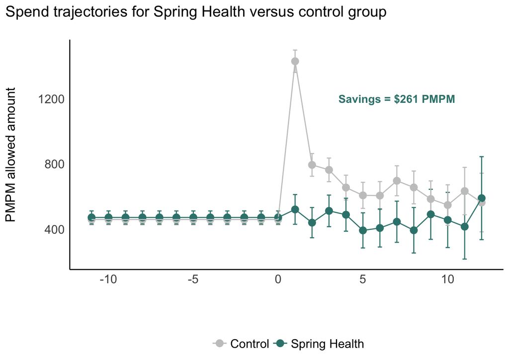

```r
# Plot
df_plot_participant_year <- df_matched %>%
  ungroup() %>%
  distinct(spring_dummy, months, months_post)

df_plot_participant_year <- predictions(m_1yr_participant, newdata = df_plot_participant_year,  re.form = ~0)
monthly_avg_did <- pull(hypotheses(m_1yr_participant, hypothesis = "b15 + b16 + b17 + b18 + b19 + b20 + b21 + b22 + b23 + b24 + b25 + b26 = 0")[2]/12)

# Overall with error bars
ggplot(df_plot_participant_year, aes(x=months, y=estimate, ymin=conf.low, ymax=conf.high, group = spring_dummy, color = spring_dummy)) +
  geom_errorbar(width = 0.25) +
  geom_point(size=3) +
  geom_line() +
  scale_color_manual(values = color_scheme, labels = c("Control", "Spring Health")) +
  annotate(geom = "text", x=7, y=1200, label = paste0("Savings = $", round(-1*monthly_avg_did, 0), " PMPM"), color = "#37837c", fontface = "bold") +
  theme_modern() +
  theme(legend.position = "bottom") +
  labs(
    title = "Spend trajectories for Spring Health versus control group",
    x = "",
    y = "PMPM allowed amount",
    color = ""
  )
```

## 8.3 Stratification by BH treatment

Do we get more savings versus the control group that did not engage in BH treatment? No.

We have more net savings on mental health spend compared to the control group members that engaged in MH care. Physical health savings are the same in both groups. Don’t love that finding as it undermines the narrative the MH treatment provides physical health savings.

Based on sessions alone, I think we can make the argument that we have more efficient care than the control group, which dovetails with what Dan Harrah was saying about Lyra’s length of care in our ROI narrative meeting. We have already shown that we get gold standard clinical outcomes due to MBC, so we can argue that at Spring people get the right amount of care and aren’t trapped in therapy endlessly after they don’t need it. But I worry that Lyra could make the argument that 4 sessions is not a full course of care and we aren’t delivering the care our patients need. Not sure how much to worry about what Lyra would say, though.

```r
# Make 3 groups
df_match_table <- df_match_table %>%
  mutate(spring_dummy_stratified = case_when(
    spring_dummy == "Control" & any_bh == "no" ~ "Control, no BH appt",
    spring_dummy == "Control" & any_bh == "yes" ~ "Control group with BH appt",
    spring_dummy == "Spring Health" ~ "Spring Health"
  ))

table1( ~ any_bh + session_count_total | spring_dummy_stratified,
        overall = F,
        render.continuous = render.cont,
        footnote = "This table is based on raw values. In cases where 2 matches were not achieved, weights were applied.",
        data=df_match_table)
```

|  | Control group with BH appt (N=3084) | Control, no BH appt (N=5982) | Spring Health (N=4905) |
| --- | --- | --- | --- |
| Engaged in outpatient behavioral health treatment |  |  |  |
| yes | 3084 (100%) | 0 (0%) | 4905 (100%) |
| no | 0 (0%) | 5982 (100%) | 0 (0%) |
| Number of behavioral health sessions, all participants |  |  |  |
| Mean (SD) | 7.31 (8.32) | 0 (0) | 4.68 (4.76) |

This table is based on raw values. In cases where 2 matches were not achieved, weights were applied.

```r
# Group by BH usage
df_matched <- df_matched %>%
  group_by(carrier_member_id) %>%
  arrange(months) %>%
  mutate(
    therapy_sessions_total = sum(spring_therapist_count_month, carrier_therapist_count_month, na.rm=T),
    session_count_total = sum(spring_tx_count_month, carrier_tx_count_month, na.rm=T)
  ) %>%
  mutate(any_bh = ifelse(session_count_total > 0, "yes", "no")) %>%
  mutate(spring_dummy_stratified = case_when(
    spring_dummy == "Health Plan" & any_bh == "no" ~ "Control, no BH appt",
    spring_dummy == "Health Plan" & any_bh == "yes" ~ "Control, yes BH appt",
    spring_dummy == "Spring" ~ "Spring Health"
  )) %>%
  mutate(spring_dummy_stratified = factor(spring_dummy_stratified, levels = c("Spring Health", "Control, no BH appt", "Control, yes BH appt")))

df_matched <- df_matched %>%
  mutate(session_count_trunc = ifelse(session_count_total > 24, 24, session_count_total))


m1_bh_overall <- lmer(med_pmpm_trunc_net ~ 1 + spring_dummy_stratified + spring_dummy_stratified:phase +
             (1 | carrier_member_id) +
             (1 | subclass_nn),
           weights = weights_nn,
           data = df_matched)

m1_bh_mh_spend <- lmer(med_pmpm_trunc_mh_net ~ 1 + spring_dummy_stratified + spring_dummy_stratified:phase +
             (1 | carrier_member_id) +
             (1 | subclass_nn),
           weights = weights_nn,
           data = df_matched)

m1_bh_nonmh_spend <- lmer(med_pmpm_trunc_nonmh ~ 1 + spring_dummy_stratified + spring_dummy_stratified:phase +
             (1 | carrier_member_id) +
             (1 | subclass_nn),
           weights = weights_nn,
           data = df_matched)

tab_model(m1_bh_overall, m1_bh_mh_spend, m1_bh_nonmh_spend,
          show.ci=F,
          show.se=T,
          pred.labels = c("Baseline Spring PMPM", "Baseline difference (Spring - Control, no BH)", "Baseline difference (Spring - Control, yes BH)", "Spring pre-post change", "Diff-in-diff (Control no BH change - Spring change)", "Diff-in-diff (Control yes BH change - Spring change)"),
          dv.labels = c("Model 1 - Total medical spend", "Model 2 - Mental health spend", "Model 3 - Physical health spend"))
```

|  | Model 1 - Total medical spend |  |  | Model 2 - Mental health spend |  |  | Model 3 - Physical health spend |  |  |
| --- | --- | --- | --- | --- | --- | --- | --- | --- | --- |
| Predictors | Estimates | std. Error | p | Estimates | std. Error | p | Estimates | std. Error | p |
| Baseline Spring PMPM | 472.64 | 20.35 | **<0.001** | 26.22 | 4.98 | **<0.001** | 446.53 | 19.58 | **<0.001** |
| Baseline difference (Spring - Control, no BH) | -34.66 | 24.29 | 0.154 | -11.34 | 6.67 | 0.089 | -22.94 | 23.33 | 0.325 |
| Baseline difference (Spring - Control, yes BH) | 31.40 | 29.80 | 0.292 | 5.57 | 7.99 | 0.486 | 26.93 | 28.62 | 0.347 |
| Spring pre-post change | 176.33 | 21.63 | **<0.001** | 186.08 | 6.19 | **<0.001** | -10.34 | 20.67 | 0.617 |
| Diff-in-diff (Control no BH change - Spring change) | 301.14 | 19.73 | **<0.001** | 123.23 | 5.64 | **<0.001** | 178.39 | 18.85 | **<0.001** |
| Diff-in-diff (Control yes BH change - Spring change) | 393.58 | 26.52 | **<0.001** | 229.27 | 7.59 | **<0.001** | 166.14 | 25.33 | **<0.001** |
| Random Effects |  |  |  |  |  |  |  |  |  |
| σ<sup>2</sup> | 9413565.44 |  |  | 776814.10 |  |  | 8588464.14 |  |  |
| τ<sub>00</sub> | 712452.41 <sub>carrier_member_id</sub> |  |  | 51534.07 <sub>carrier_member_id</sub> |  |  | 664365.12 <sub>carrier_member_id</sub> |  |  |
|  | 494634.15 <sub>subclass_nn</sub> |  |  | 2095.20 <sub>subclass_nn</sub> |  |  | 464822.00 <sub>subclass_nn</sub> |  |  |
| ICC | 0.11 |  |  | 0.06 |  |  | 0.12 |  |  |
| N | 13971 <sub>carrier_member_id</sub> |  |  | 13971 <sub>carrier_member_id</sub> |  |  | 13971 <sub>carrier_member_id</sub> |  |  |
|  | 4908 <sub>subclass_nn</sub> |  |  | 4908 <sub>subclass_nn</sub> |  |  | 4908 <sub>subclass_nn</sub> |  |  |
| Observations | 256996 |  |  | 257007 |  |  | 257007 |  |  |
| Marginal R<sup>2</sup> / Conditional R<sup>2</sup> | 0.002 / 0.115 |  |  | 0.009 / 0.073 |  |  | 0.001 / 0.117 |  |  |

## 8.4 Drop those with month 1 inpatient spend

```r
df_matched <- df_matched %>%
  group_by(subclass_nn) %>%
  mutate(
    ip_month1 = sum(med_pmpm_trunc_ip_nonmh[months==1], na.rm=T),
    ip_months1_to_3 = sum(med_pmpm_trunc_ip_nonmh[months==1 | months==2 | months==3], na.rm=T)
    )

m1_drop_month1_ip <- lmer(med_pmpm_trunc_net ~ 1 + spring_dummy + spring_dummy*phase +
             (1 | carrier_member_id) +
             (1 | subclass_nn),
           weights = weights_nn,
           data = filter(df_matched, ip_month1==0))

tab_model(m1_net, m1_drop_month1_ip, show.ci=F, show.se=T,
          dv.labels = c("All participants", "Drop participants with month 1 inpatient physical health spend"))
```

|  | All participants |  |  | Drop participants with month 1 inpatient physical health spend |  |  |
| --- | --- | --- | --- | --- | --- | --- |
| Predictors | Estimates | std. Error | p | Estimates | std. Error | p |
| (Intercept) | 460.40 | 16.49 | **<0.001** | 430.76 | 14.36 | **<0.001** |
| spring dummy [Spring] | 12.25 | 22.03 | 0.578 | 9.35 | 20.21 | 0.644 |
| phase [post_tx] | 334.91 | 15.83 | **<0.001** | 282.87 | 14.66 | **<0.001** |
| spring dummy [Spring] × phase [post_tx] | -158.82 | 26.75 | **<0.001** | -107.03 | 24.78 | **<0.001** |
| Random Effects |  |  |  |  |  |  |
| σ<sup>2</sup> | 9413713.26 |  |  | 7876057.09 |  |  |
| τ<sub>00</sub> | 714735.34 <sub>carrier_member_id</sub> |  |  | 572450.14 <sub>carrier_member_id</sub> |  |  |
|  | 493506.82 <sub>subclass_nn</sub> |  |  | 295442.58 <sub>subclass_nn</sub> |  |  |
| ICC | 0.11 |  |  | 0.10 |  |  |
| N | 13971 <sub>carrier_member_id</sub> |  |  | 13593 <sub>carrier_member_id</sub> |  |  |
|  | 4908 <sub>subclass_nn</sub> |  |  | 4780 <sub>subclass_nn</sub> |  |  |
| Observations | 256996 |  |  | 250122 |  |  |
| Marginal R<sup>2</sup> / Conditional R<sup>2</sup> | 0.002 / 0.115 |  |  | 0.002 / 0.101 |  |  |